# Corporate Communication During Economic Crises: A Text Mining Analysis of CEO Departurese

Author

Jelizaveta Tsalaja

## Overview

This analysis investigates how corporate communication changes during economic crises by examining 3,547 CEO departure announcements from S&P 1500 firms (2003-2014), comparing the 2008-2009 financial crisis to stable periods.

**Research Question:** Do CEO departure narratives fundamentally change during economic crises?

**Methods:** Text mining using unsupervised learning (LDA topic modeling, keyness analysis, k-medoids clustering, BERTopic transformer-based semantic analysis)

**Key Finding:** Crises recalibrate rather than rupture corporate communication, shifting vocabulary externalization and thematic emphasis while maintaining similar narrative structures.

## Part A: Similarity

### Importing Libraries

We start our work by loading all of the libraries that will be necessary throughout Parts A and B. To install and load libraries in one go we are using `p_load()`.

```r
# Note on reproducibility:
# To make code install packages on other computers please uncomment the install.packages() commands below
#install.packages("devtools")
library(devtools)
#install.packages("pacman")
library(pacman)

p_load(readr)
p_load(tidytuesdayR)
p_load(tidyverse)
p_load(naniar)
p_load(quanteda)
p_load(topicmodels)
p_load(tidytext)
p_load(bertopicr)
p_load(janitor)
p_load(quanteda.textstats)
p_load(seededlda)
p_load(udpipe)
p_load(isotree)
p_load(plotly)
p_load(bertopicr)
p_load(cluster)
p_load(dbscan)
p_load(quanteda.textplots)
p_load(factoextra)
p_load(quanteda.textmodels)
p_load(uwot)
p_load(stm)
p_load(doParallel)
p_load(topicdoc)
p_load(reticulate)
```

### Data Source and Reproducibility

This analysis uses the CEO Departures dataset from Tidy Tuesday (2021, Week 18), which contains 9,423 CEO departure events from S&P 1500 firms between 1987 and 2020.

**Data access:** The dataset is loaded using the `tidytuesdayR` package, which provides a standardized interface to Tidy Tuesday datasets.

**Required packages:** `tidytuesdayR` (install with: `install.packages("tidytuesdayR")`)

**To reproduce this analysis:** Run the code below to automatically fetch the data

```r
# Load data using tidytuesdayR package
tuesdata <- tidytuesdayR::tt_load(2021, week = 18)
```

```
---- Compiling #TidyTuesday Information for 2021-04-27 ----
--- There is 1 file available ---


── Downloading files ───────────────────────────────────────────────────────────

  1 of 1: "departures.csv"
```

```r
departures <- tuesdata$departures
```

**Alternative if URL is unavailable:** If the Tidy Tuesday package becomes inaccessible, please download the dataset manually from: https://github.com/rfordatascience/tidytuesday/tree/master/data/2021/2021-04-27 and save it as as `data/departures.csv`. Then, to access data and reproduce the code modify the code chunk above to: `departures <- read_csv('data/departures.csv')`

Once we have ensured data accessibilty and reproducibility, we can view our dataset. The datatset has 19 variables and 9,423 observations.

```r
# View our data
glimpse(departures)
```

```
Rows: 9,423
Columns: 19
$ dismissal_dataset_id <dbl> 559043, 12, 13, 31, 43, 51, 61, 63, 62, 65, 75, 7…
$ coname               <chr> "SONICBLUE INC", "AMERICAN AIRLINES GROUP INC", "…
$ gvkey                <dbl> 27903, 1045, 1045, 1078, 1161, 1177, 1194, 1194, …
$ fyear                <dbl> 2002, 1997, 2002, 1998, 2001, 1997, 1993, 1997, 1…
$ co_per_rol           <dbl> -1, 1, 3, 6, 11, 16, 21, 22, 24, 28, 33, 34, 38, …
$ exec_fullname        <chr> "L. Gregory Ballard", "Robert L. Crandall", "Dona…
$ departure_code       <dbl> 7, 5, 3, 5, 5, 5, 5, 7, 9, 5, 5, 5, 3, 5, 5, 3, 3…
$ ceo_dismissal        <dbl> 0, 0, 1, 0, 0, 0, 0, 0, NA, 0, 0, 0, 1, 0, 0, 1, …
$ interim_coceo        <chr> NA, NA, NA, NA, NA, NA, NA, NA, NA, NA, NA, NA, N…
$ tenure_no_ceodb      <dbl> 1, 1, 1, 1, 1, 1, 1, 1, 1, 1, 1, 1, 1, 1, 1, 1, 1…
$ max_tenure_ceodb     <dbl> 1, 1, 1, 1, 1, 1, 1, 1, 1, 1, 1, 1, 1, 1, 1, 1, 1…
$ fyear_gone           <dbl> 2003, 1998, 2003, 1998, 2002, 1997, 1993, 1998, 1…
$ leftofc              <dttm> 2003-03-21, 1998-05-20, 2003-04-24, 1998-12-31, …
$ still_there          <chr> NA, NA, NA, NA, NA, NA, NA, NA, NA, NA, NA, NA, N…
$ notes                <chr> "Ballard took over when the outgoing CEO said tha…
$ sources              <chr> "https://www.wsj.com/articles/SB10288576921909334…
$ eight_ks             <chr> "https://www.sec.gov/Archives/edgar/data/850519/0…
$ cik                  <dbl> 850519, 6201, 6201, 1800, 2488, 1122304, 771667, …
$ `_merge`             <chr> "matched (3)", "matched (3)", "matched (3)", "mat…
```

With the help of GitHub repository, which contains the descriptions of the variables, we can create a table containing simple explanations of each variable.

| Variable | Description |
| --- | --- |
| dismissal_dataset_id | Unique identifier for each departure event (primary key) |
| coname | Company name (from Compustat database) |
| gvkey | Company identifier (from Compustat database) |
| fyear | Fiscal year when the departure occurred |
| co_per_rol | Executive/company identifier (from Execucomp database) |
| exec_fullname | Full name of the departing CEO |
| departure_code | Numerical code indicating reason for departure |
| ceo_dismissal | Binary indicator: 1 = involuntary departure (non-health related), 0 = voluntary |
| interim_coceo | Indicates if CEO was serving as interim or co-CEO |
| tenure_no_ceodb | For returning CEOs, indicates which tenure period (first, second, etc.) |
| max_tenure_ceodb | Total number of times this person served as CEO of this company |
| fyear_gone | Fiscal year of the CEO’s effective departure date |
| leftofc | Date when CEO officially left office |
| still_there | Date when CEO status was last verified (if still in office) |
| notes | Narrative text describing departure circumstances and justification for coding |
| sources | URLs of internet or library sources documenting the departure |
| eight_ks | URLs of relevant SEC 8-K filings (270 days before/after departure) |
| cik | Company’s Central Index Key (SEC identifier) |
| _merge | Technical variable from data merge process |

We can see that our dataset has a lot of information. Let’s identify the most useful variables for our analysis.

**Key variables of interest:**

- notes: narrative text (main text field for analysis)
- departure_code: reason for departure
- fyear: year of departure
- coname: company name

To further understand the dataset we can explore what percentage of our key variables are missing.

```r
# We check for missingness in key variables
departures |>
  select(notes, departure_code, fyear, coname) |>
  naniar::miss_var_summary()
```

```
# A tibble: 4 × 3
  variable       n_miss pct_miss
  <chr>           <int>    <num>
1 departure_code   1667     17.7
2 notes            1644     17.4
3 fyear               0      0
4 coname              0      0
```

To further understand missing data, we can visualise it.

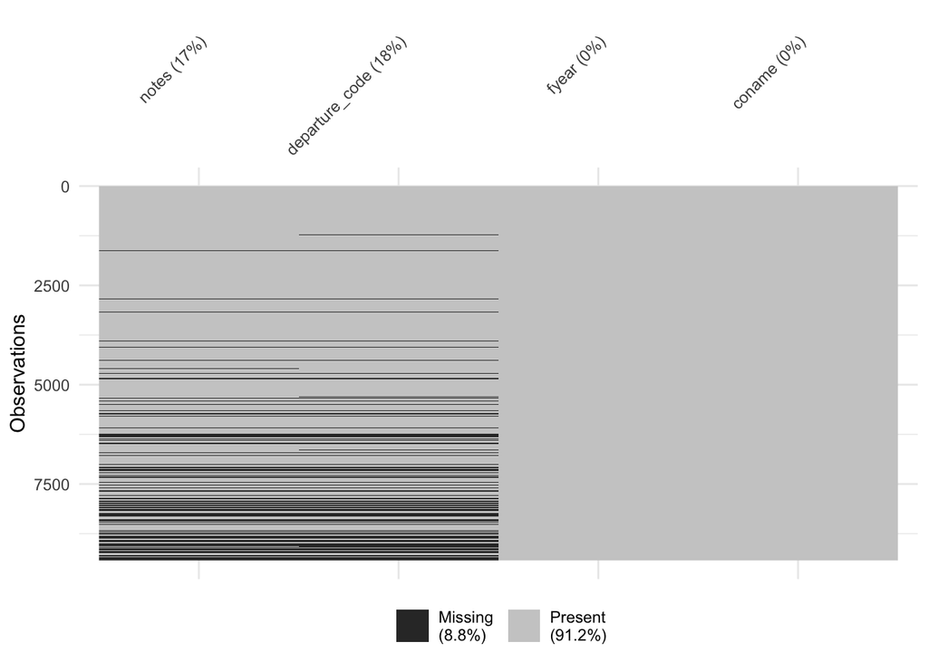

```r
# We also plot the missing data
naniar::vis_miss(departures |>
                   select(notes, departure_code, fyear, coname)) +
    theme(axis.text.x = element_text(angle = 45, hjust = 1))
```

We can see that the departure code and notes (text) are almost always missing together. Since it is not a numerical data but text, we will not impute it. Thus, we will continue our analysis without the missing notes and, for convenience, without the entries that do not have departure code.

Let’s consider how long the notes of our text are on average.

```r
# We next find count of characters in each note
departures_len <- departures |>
  mutate(text_length = str_length(notes))

# Create summary statistics of node length
departures_len |>
  filter(!is.na(notes)) |>
  summarise(
    min_length = min(text_length),
    median_length = median(text_length),
    mean_length = mean(text_length),
    max_length = max(text_length)
  )
```

```
# A tibble: 1 × 4
  min_length median_length mean_length max_length
       <int>         <int>       <dbl>      <int>
1          5           313        376.       3117
```

As we can see, the shortest note is 5 characters, while the longest one is 3,117 characters. This indicates a significant variation in note length. Let’s now look at the distribution of the text length.

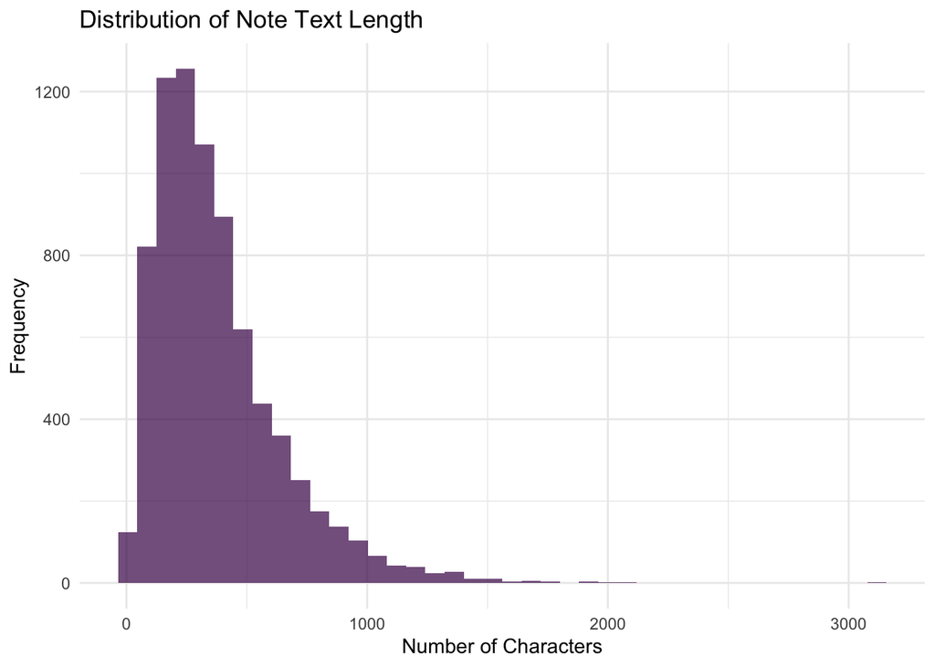

```r
# We plot the distribution of note text
departures_len |>
  filter(!is.na(notes)) |>
  filter(!is.na(departure_code)) |>
  ggplot(aes(x = text_length, fill = "Notes")) +
  geom_histogram(bins = 40, alpha = 0.7) +
  scale_fill_viridis_d(guide = "none") +
  labs(
    title = "Distribution of Note Text Length",
    x = "Number of Characters",
    y = "Frequency"
  ) +
  theme_minimal()
```

From the plot we can identify that majority of the notes are within the length of 0-1000 characters, which is approximately 0-200 words. We will keep this in mind when looking for similar and different notes.

##### Data Cleaning

Additionaly, from the original dataset of 19 variables, we decided to retain only those essential for text analysis and interpretation:

**Variables kept:**

- **Text**: `notes` (departure narrative - primary analysis variable)
- **Identifiers**: `dismissal_dataset_id`, `coname`, `exec_fullname`
- **Year**: `fyear` (year of departure)
- **Categorization**: `departure_code`, `ceo_dismissal`

**Derived variables created:**

- `departure_type` - readable labels for departure codes
- `text_length` - number of characters in notes

This selection maintains clarity while preserving all information necessary for interpreting similarity patterns and anomalies in CEO departures.

```r
# Exclude observations without note text and departure code
departures_clean <- departures |>
  filter(!is.na(notes)) |>
  filter(!is.na(departure_code)) |>

  # Select the variables we will use
  select(
    dismissal_dataset_id,      # Unique identifier
    coname,                    # Company name
    exec_fullname,             # CEO name
    fyear,                     # Year of departure
    departure_code,            # Reason code
    ceo_dismissal,             # Involuntary dummy variable
    notes                      # Text we will analyze
  ) |>

  # We also add derived variable - label for departure codes from
  # https://github.com/rfordatascience/tidytuesday/tree/main/data/2021/2021-04-27
  mutate(
    departure_type = case_when(
      departure_code == 1 ~ "Death",
      departure_code == 2 ~ "Illness",
      departure_code == 3 ~ "Job performance",
      departure_code == 4 ~ "Legal violations",
      departure_code == 5 ~ "Retired",
      departure_code == 6 ~ "New Opportunity",
      departure_code == 7 ~ "Other",
      departure_code == 8 ~ "Unknown Reason",
      departure_code == 9 ~ "No Reason",
      TRUE ~ "Other"
    ),
    text_length = str_length(notes))

# Verify
glimpse(departures_clean)
```

```
Rows: 7,724
Columns: 9
$ dismissal_dataset_id <dbl> 559043, 12, 13, 31, 43, 51, 61, 63, 62, 65, 75, 7…
$ coname               <chr> "SONICBLUE INC", "AMERICAN AIRLINES GROUP INC", "…
$ exec_fullname        <chr> "L. Gregory Ballard", "Robert L. Crandall", "Dona…
$ fyear                <dbl> 2002, 1997, 2002, 1998, 2001, 1997, 1993, 1997, 1…
$ departure_code       <dbl> 7, 5, 3, 5, 5, 5, 5, 7, 9, 5, 5, 5, 3, 5, 5, 3, 3…
$ ceo_dismissal        <dbl> 0, 0, 1, 0, 0, 0, 0, 0, NA, 0, 0, 0, 1, 0, 0, 1, …
$ notes                <chr> "Ballard took over when the outgoing CEO said tha…
$ departure_type       <chr> "Other", "Retired", "Job performance", "Retired",…
$ text_length          <int> 375, 226, 228, 353, 159, 184, 177, 436, 250, 205,…
```

##### Lemmatization

Now that we have a cleaned dataset, we can move on to working with it. We choose to implement lemmatization as it preserves accurate and interpretable results. Given that our goal further on is to find similar documents via topic modeling, lemmatization with UDPipe is the right choice, as it works with big datasets as ours and produces real words that are easy to interpret.

```r
# We download and load an English model
model <- udpipe::udpipe_download_model(language = "english-ewt")
```

```
Downloading udpipe model from https://raw.githubusercontent.com/jwijffels/udpipe.models.ud.2.5/master/inst/udpipe-ud-2.5-191206/english-ewt-ud-2.5-191206.udpipe to /Users/jelizavetatsalaja/Documents/english-ewt-ud-2.5-191206.udpipe
```

```
 - This model has been trained on version 2.5 of data from https://universaldependencies.org
```

```
 - The model is distributed under the CC-BY-SA-NC license: https://creativecommons.org/licenses/by-nc-sa/4.0
```

```
 - Visit https://github.com/jwijffels/udpipe.models.ud.2.5 for model license details.
```

[output not shown]

```
Downloading finished, model stored at '/Users/jelizavetatsalaja/Documents/english-ewt-ud-2.5-191206.udpipe'
```

```r
ud_model <- udpipe::udpipe_load_model(model$file_model)

# Select text
ceo_texts <- departures_clean$notes

# Lemmatize the text
ud_out <- udpipe::udpipe(ceo_texts, ud_model)

# Reconstruct documents from lemmas
lemma_texts <- ud_out |>
  group_by(doc_id) |>
  summarise(text = paste(lemma, collapse = " "), .groups = "drop") |>
  mutate(doc_num = as.integer(str_extract(doc_id, "\\d+"))) |>
  arrange(doc_num) |>
  select(-doc_num)

# Add to departures_clean for easier access and comparison
departures_clean$lemma_text <- lemma_texts$text
```

Now that we have our lemmatized texts, we can build a corpus.

##### Building a Corpus

When building our corpus, we choose to remove punctuation, symbols, URLs, and separators, but retain numbers. Numerical information such as executive ages, tenure lengths, and financial amounts might provide useful context about departure circumstances in these corporate announcements. Additionally, as recommended in Week 11 lecture, we choose to keep the stopwords, excluding only a small set of them that are extremely frequent.

```r
# Create corpus from lemmatized text
corp_lemma <- corpus(departures_clean, text_field = "lemma_text")

# Next, we can tokenize the texts
tokens_lemma <- tokens(
  corp_lemma,
  remove_punct = TRUE,
  remove_symbols = TRUE,
  remove_numbers = FALSE,
  remove_url = TRUE,
  remove_separators = TRUE
) |>
  tokens_tolower()

# We remove extra frequent words
ultra_stop <- c("the","a","an","to","of","in","and","for","on","is","it", "ceo", "chief", "executive", "officer")

# Next, we remove domain-specific stopwords
tokens_lemma <- tokens_remove(tokens_lemma, ultra_stop)
```

Next in our pre-processing, we choose to create unigrams and bigrams. We do that to capture meaningful phrases common in corporate announcements. Bigrams like “poor performance” and “step down” might offer distinct meanings that would be lost if these words appeared separately.

As we create these n-grams and DFM, we choose to removes words appearing in fewer than 2 documents. We decide to apply such minimal feature trimming, as this preserves vocabulary for topic modeling while eliminating obvious noise. LDA, which we will apply later, handles rare terms without requiring aggressive pre-filtering.

```r
# We create n-grams (unigrams + bigrams)
tokens_ngrams <- tokens_ngrams(tokens_lemma, n = 1:2)

# Now we create DFM
dfm_ceo <- dfm(tokens_ngrams)

# Next we display top features
topfeatures(dfm_ceo, 20)
```

```
       be        as        he   company         s  chairman      have     board
    11713      8656      8610      8478      5099      4742      4614      4438
president        mr      from      that      will      with       inc  director
     3965      3819      3753      3647      3416      2973      2931      2775
     year        by     serve        at
     2768      2103      2082      2061
```

```r
# We also choose to trim super rare features that appear in less than 2 documents
dfm_ceo <- dfm_trim(
  dfm_ceo,
  min_docfreq = 2, # Appears in ≥2 docs
  docfreq_type = "count"
)

# Final dimensions
dim(dfm_ceo)
```

```
[1]  7724 42198
```

### Applying LDA: Latent Dirichlet Allocation

Now, we are ready to find similar documents. To do that, we will use LDA: Latent Dirichlet Allocation. We choose Latent Dirichlet Allocation (LDA) to identify similar CEO departure narratives because corporate announcements follow patterns based on departure circumstances. LDA will help us to discover these thematic patterns without requiring pre-defined categories.

We want to identify which departures are similar to each other and LDA directly answers this by grouping documents with shared vocabulary patterns into topics. Documents that we can assign to the same topic are similar because they might discuss departures under similar circumstances, such as planned retirements versus performance-related exits. Since we have numeric data such as departure code, we will be able to test whether LDA’s topic assignments align with the hand-coded departure reasons (departure_code), providing validation that the model identifies substantively meaningful groupings. If topics correspond to specific departure codes (e.g., retirements, performance issues, legal violations), this would confirm that LDA successfully discovers the underlying circumstances that might make departures similar.

```r
# We create a function to fit LDA with different K values
fit_lda_model <- function(dfm_lda, k, n_terms = 15) {
  set.seed(42)

  # Fit LDA
  lda_model <- LDA(
    dfm_lda,
    k = k,
    method = "Gibbs",
    control = list(
      seed = 42,
      burnin = 1000,
      iter = 3000,
      thin = 100
    )
  )

  # We next get top terms as matrix
  terms_matrix <- topicmodels::terms(lda_model, n_terms)

  # We convert to tibble for better display
  terms_tibble <- as_tibble(terms_matrix) |>
    mutate(rank = row_number()) |>
    select(rank, everything())

  return(list(
    model = lda_model,
    terms = terms_tibble
  ))
}

# Convert dfm to needed format
dfm_lda <- convert(dfm_ceo, to = "topicmodels")

# Try different K values
lda_k4 <- fit_lda_model(dfm_lda, k = 4, n_terms = 15)
lda_k5 <- fit_lda_model(dfm_lda, k = 5, n_terms = 15)
lda_k6 <- fit_lda_model(dfm_lda, k = 6, n_terms = 15)
lda_k7 <- fit_lda_model(dfm_lda, k = 7, n_terms = 15)
lda_k8 <- fit_lda_model(dfm_lda, k = 8, n_terms = 15)

# View terms for comparison
lda_k4$terms
```

```
# A tibble: 15 × 5
    rank `Topic 1` `Topic 2` `Topic 3` `Topic 4`
   <int> <chr>     <chr>     <chr>     <chr>
 1     1 inc       be        s         as
 2     2 be        he        as        from
 3     3 its       company   will      president
 4     4 with      that      board     mr
 5     5 company   year      he        company
 6     6 s         with      chairman  chairman
 7     7 by        after     have      be
 8     8 merger    not       retire    he
 9     9 share     this      company   serve
10    10 corp      by        that      board
11    11 stock     leave     announce  director
12    12 million   s         step      serve_as
13    13 have      resign    effective since
14    14 agreement say       company_s chairman_board
15    15 billion   time      step_down have
```

```r
lda_k5$terms
```

```
# A tibble: 15 × 6
    rank `Topic 1` `Topic 2`   `Topic 3` `Topic 4`      `Topic 5`
   <int> <chr>     <chr>       <chr>     <chr>          <chr>
 1     1 year      inc         be        board          as
 2     2 company   be          he        as             from
 3     3 s         with        company   will           chairman
 4     4 have      merger      that      s              president
 5     5 after     share       mr        chairman       mr
 6     6 say       by          with      retire         he
 7     7 down      stock       not       company        serve
 8     8 step      corp        resign    director       company
 9     9 be        its         leave     announce       be
10    10 step_down agreement   this      board_director serve_as
11    11 at        company     time      president      since
12    12 its       billion     by        company_s      chairman_board
13    13 with      acquire     as        effective      director
14    14 over      will        but       that           until
15    15 that      corporation he_be     have           as_chairman
```

```r
lda_k6$terms
```

```
# A tibble: 15 × 7
    rank `Topic 1` `Topic 2`      `Topic 3`   `Topic 4`  `Topic 5`   `Topic 6`
   <int> <chr>     <chr>          <chr>       <chr>      <chr>       <chr>
 1     1 s         board          be          he         inc         as
 2     2 have      will           company     as         be          from
 3     3 company   s              mr          year       merger      chairman
 4     4 be        president      that        after      share       president
 5     5 say       director       not         down       stock       serve
 6     6 its       announce       he          step       with        mr
 7     7 year      as             this        step_down  billion     be
 8     8 that      board_director resign      retire     agreement   company
 9     9 million   company        leave       at         acquire     serve_as
10    10 new       have           with        position   by          since
11    11 would     chairman       by          with       will        director
12    12 by        effective      do          retirement corp        board
13    13 than      company_s      departure   chairman   corporation until
14    14 more      that           resignation remain     its         chairman_b…
15    15 at        who            other       company    acquisition have
```

```r
lda_k7$terms
```

```
# A tibble: 15 × 8
    rank `Topic 1` `Topic 2`   `Topic 3` `Topic 4` `Topic 5` `Topic 6` `Topic 7`
   <int> <chr>     <chr>       <chr>     <chr>     <chr>     <chr>     <chr>
 1     1 be        board       inc       be        he        company   as
 2     2 inc       as          merger    mr        as        have      from
 3     3 corp      will        share     that      year      s         chairman
 4     4 company   s           be        company   after     be        president
 5     5 new       president   company   not       down      year      serve
 6     6 will      director    with      he        step      its       mr
 7     7 become    board_dire… stock     resign    retire    say       serve_as
 8     8 base      company     agreement this      step_down that      company
 9     9 s         chairman    corporat… leave     position  with      be
10    10 by        announce    announce  do        chairman  more      since
11    11 its       effective   by        departure retireme… than      chairman…
12    12 billion   have        acquisit… as        at        million   until
13    13 say       company_s   which     by        remain    after     director
14    14 at        that        into      but       role      have_be   board
15    15 co        who         sharehol… resignat… from      over      have
```

```r
lda_k8$terms
```

```
# A tibble: 15 × 9
    rank `Topic 1`   `Topic 2` `Topic 3` `Topic 4` `Topic 5` `Topic 6` `Topic 7`
   <int> <chr>       <chr>     <chr>     <chr>     <chr>     <chr>     <chr>
 1     1 inc         he        board     be        be        chairman  s
 2     2 merger      as        director  mr        he        will      company
 3     3 share       year      as        company   company   president have
 4     4 stock       after     board_di… resign    that      be        its
 5     5 acquire     down      company   with      leave     who       year
 6     6 billion     step      announce  as        have      become    say
 7     7 corporation step_down have      by        not       as        million
 8     8 acquisition retire    s         s         he_be     s         that
 9     9 with        from      that      that      but       name      more
10    10 by          position  effective from      this      company   than
11    11 agreement   retireme… company_s resignat… change    as_chair… at
12    12 group       at        president other     do        succeed   sale
13    13 bank        with      today     inc       when      new       business
14    14 corp        plan      announce… resign_as take      corp      quarter
15    15 be          role      1         agreement company_… retire    would
# ℹ 1 more variable: `Topic 8` <chr>
```

Following Week 11 guidance that “interpretability always wins” over quantitative metrics, we select K = 6 based on qualitative assessment of topic coherence and distinctiveness. Specifically, we chose K=6 because:

- K=4 produced overly broad topics with mostly generic terms (‘be’, ‘he’, ‘company’) that were difficult to distinguish thematically
- K=7-8 separated notes into overlapping topics with more vocabulary redundancy
- K=6 created the best balance, producing six topics with distinct, interpretable vocabulary

| Topic | Interpretation / Theme | Example Top Words |
| --- | --- | --- |
| **1. Financial & Business Context** | Departures discussed with financial details, business metrics, and company changes | s, have, company, be, say, its, year, that, million, new, would |
| **2. Board Succession Planning** | Formal board announcements of transitions, planned successions, effective dates | board, will, s, president, director, announce, as, board_director, company, have |
| **3. Resignation Language** | General resignation announcements, departures without extensive detail | be, company, mr, that, not, he, this, resign, leave, with, departure, resignation |
| **4. Step-Downs & Retirements** | CEOs stepping down or retiring, often with continued involvement | he, as, year, after, down, step, step_down, retire, from, position |
| **5. Merger & Acquisition Activity** | CEO changes during M&A transactions, acquisitions, shareholder agreements | inc, be, merger, share, stock, with, billion, agreement, acquire, by |
| **6. Leadership Transitions** | Succession to new roles, becoming chairman, serving in positions | as, from, chairman, president, serve, mr, be, company, serve_as, since |

After fitting the LDA model, we assign each departure narrative to its most prominent topic. Since LDA is probabilistic, each document has a distribution across all topics, but we use the topic with the highest probability as the document’s “dominant topic” for interpretation.

This creates our final dataset where each CEO departure is labeled with its topic assignment, allowing us to validate whether LDA’s unsupervised groupings align with the hand-coded departure reasons and look for simmilar documents.

```r
# We choose the optimal k
lda_model <- lda_k6$model

# We get topic proportions for each document in the LDA
doc_topics <- topicmodels::posterior(lda_model)$topics

# Get metadata from dfm_ceo
ceo_metadata <- as.data.frame(docvars(dfm_ceo))

# Find non-empty docs
row_sums <- slam::row_sums(dfm_lda)
non_empty_idx <- which(row_sums > 0)

# Filter metadata to match LDA docs
ceo_metadata_lda <- ceo_metadata[non_empty_idx, ]

# Build topic-labeled table
topic_df <- cbind(
  ceo_metadata_lda,
  dominant_topic = topicmodels::topics(lda_model, 1)
)

topic_df <- tibble::as_tibble(topic_df)

# View
head(topic_df, 10)
```

```
# A tibble: 10 × 10
   dismissal_dataset_id coname  exec_fullname fyear departure_code ceo_dismissal
                  <dbl> <chr>   <chr>         <dbl>          <dbl>         <dbl>
 1               559043 SONICB… L. Gregory B…  2002              7             0
 2                   12 AMERIC… Robert L. Cr…  1997              5             0
 3                   13 AMERIC… Donald J. Ca…  2002              3             1
 4                   31 ABBOTT… Duane L. Bur…  1998              5             0
 5                   43 ADVANC… Walter Jerem…  2001              5             0
 6                   51 AETNA … Ronald Edwar…  1997              5             0
 7                   61 AHMANS… Richard H. D…  1993              5             0
 8                   63 AHMANS… Charles R. R…  1997              7             0
 9                   62 AHMANS… Robert M. De…  1993              9            NA
10                   65 AIR PR… Harold A. Wa…  2000              5             0
# ℹ 4 more variables: notes <chr>, departure_type <chr>, text_length <int>,
#   dominant_topic <int>
```

We can create summary of what identified topics align with which departure codes.

```r
# We create summary of the topics
topic_df |>
  count(departure_code, departure_type, dominant_topic) |>
  group_by(departure_code) |>
  slice_max(n, n = 1) |>  # Most common topic per code
  select(departure_code, departure_type, dominant_topic) |>
  tibble()
```

```
# A tibble: 9 × 3
  departure_code departure_type   dominant_topic
           <dbl> <chr>                     <int>
1              1 Death                         4
2              2 Illness                       4
3              3 Job performance               3
4              4 Legal violations              3
5              5 Retired                       4
6              6 New Opportunity               2
7              7 Other                         5
8              8 Unknown Reason                3
9              9 No Reason                     3
```

##### Validating Topics Against Departure Codes

To assess whether LDA discovered meaningful patterns, we examine how the departure reasons (departure_code) distribute across our six topics.

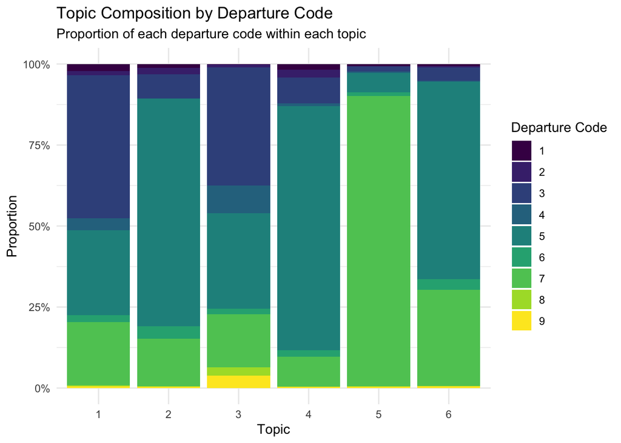

```r
# We create a visualisation of topic distribution by departure code
topic_df |>
  count(dominant_topic, departure_code) |>
  group_by(dominant_topic) |>
  mutate(prop = n / sum(n)) |>
  ggplot(aes(x = factor(dominant_topic), y = prop, fill = factor(departure_code))) +
  geom_col() +
  scale_y_continuous(labels = scales::percent) +
  scale_fill_viridis_d() +
  labs(
    title = "Topic Composition by Departure Code",
    subtitle = "Proportion of each departure code within each topic",
    x = "Topic",
    y = "Proportion",
    fill = "Departure Code"
  ) +
  theme_minimal()
```

##### Visualisation Analysis

The visualisation shows us that LDA found meaningful patterns. Each topic aligns with some departure codes:

**Strong alignments:**

- Topic 5 which we identified as M&A topic is mostly Code 7 (bright green) which indicates the collective ‘Other’ category
- Topic 2, 4, 6 are heavily Code 5, which indicates retirement

**Mixed topics:**

- **Topic 1, 3** are mixed but have lots of Code 3, which indicates departure due to the job performace

Overall, we can see that Topics 1, 2, 3, 4 and 6 all contain significant amounts of Code 5 (Retired). This isn’t a problem, because if we look at how the departure codes are distributed throughout our dataset, we will see that retirement is the most popular option, as it represents 46% of CEO departures.

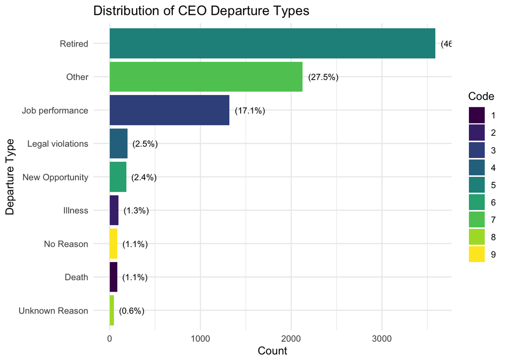

```r
# Bar plot of departure codes
topic_df |>
  count(departure_code, departure_type) |>
  mutate(prop = n / sum(n)) |>
  ggplot(aes(x = reorder(departure_type, n), y = n,  fill = factor(departure_code))) +
  geom_col() +
  geom_text(aes(label = paste0(" (", round(prop*100, 1), "%)")), hjust = -0.1, size = 3) +
  coord_flip() +
  scale_fill_viridis_d() +
  labs(
    title = "Distribution of CEO Departure Types",
    x = "Departure Type",
    y = "Count",
    fill = "Code"
  ) +
  theme_minimal()
```

**Identifying Similar Departures**

Now that we’ve identified six topics, we can find which specific CEO departures are similar to each other by examining which documents share the same dominant topic or have similar topic distributions.

```r
# Top 5 departures per topic
doc_topics <- posterior(lda_model)$topics

topic_df <- topic_df |>
  mutate(
    topic_1 = doc_topics[, 1],
    topic_2 = doc_topics[, 2],
    topic_3 = doc_topics[, 3],
    topic_4 = doc_topics[, 4],
    topic_5 = doc_topics[, 5],
    topic_6 = doc_topics[, 6]
  )

# Now we show top 5 by probability
all_top_examples <- map_df(1:6, function(i) {
  topic_df |>
    arrange(desc(.data[[paste0("topic_", i)]])) |>
    slice_head(n = 3) |>
    mutate(
      topic = i,
      probability = .data[[paste0("topic_", i)]]
    ) |>
    select(topic, coname, fyear, departure_code, departure_type, probability, notes)
})

all_top_examples
```

```
# A tibble: 18 × 7
   topic coname            fyear departure_code departure_type probability notes
   <int> <chr>             <dbl>          <dbl> <chr>                <dbl> <chr>
 1     1 PIER 1 IMPORTS I…  2016              3 Job performan…       0.636 "Smi…
 2     1 STARBUCKS CORP     2007              3 Job performan…       0.605 "SEA…
 3     1 STATE STREET CORP  2003              2 Illness              0.577 "In …
 4     2 PARKER DRILLING …  2009              5 Retired              0.635 "HOU…
 5     2 ESSENDANT INC      2017              6 New Opportuni…       0.616 "Jul…
 6     2 DANA INC           2010              7 Other                0.588 "PRE…
 7     3 CASTLE (A M) & CO  2014              3 Job performan…       0.711 "Mr.…
 8     3 TOYS R US INC      2005              3 Job performan…       0.668 "Mar…
 9     3 PHILADELPHIA CON…  2007              4 Legal violati…       0.657 "Mr.…
10     4 KIMCO REALTY CORP  2009              5 Retired              0.499 "Dav…
11     4 JONES GROUP INC    2001              7 Other                0.493 "Kim…
12     4 KNIGHT-SWIFT TRP…  2014              5 Retired              0.471 "Kni…
13     5 PARKWAY PROPERTI…  2015              7 Other                0.714 "Oct…
14     5 FIRSTMERIT CORP    2015              7 Other                0.708 "Eff…
15     5 MANOR CARE INC-O…  1996              7 Other                0.707 "Ste…
16     6 DSP GROUP INC      2004              5 Retired              0.717 "Eli…
17     6 ELECTRONICS BOUT…  2004              7 Other                0.701 "Mr.…
18     6 CLOUD PEAK ENERG…  2018              7 Other                0.690 "Col…
```

Looking at the top examples for each topic, we see interesting probability patterns.

What this means: CEO departure announcements often blend themes. For example, Kimco Realty’s retirement (Topic 4, probability 0.50) sits right at the boundary, suggesting it combines retirement language with other narrative elements. Similarly, Jones Group’s departure (Topic 4, probability 0.49) barely qualifies as its dominant topic, indicating it draws equally from multiple themes. This mixing is realistic since a retirement might also discuss financial performance, or a resignation might include succession planning details. The moderate probabilities (not 0.90+) show that LDA captures this complexity rather than forcing each departure into rigid categories.

Now, let’s look at the documents specifically. For readability purposes, we will do it topic by topic.

**Topic 1**

```r
# We display Topic 1 examples only
cat("=== TOPIC 1: Most Representative Departures ===\n")
```

```
=== TOPIC 1: Most Representative Departures ===
```

```r
topic_1_examples <- all_top_examples %>% filter(topic == 1)

for(j in 1:3) {
  cat("\nExample", j, ":", topic_1_examples$coname[j],
      "(", topic_1_examples$fyear[j], ")\n")
  cat(topic_1_examples$notes[j], "\n")
 }
```

```
Example 1 : PIER 1 IMPORTS INC/DE ( 2016 )
Smith's departure comes as the company also said Wednesday that sales fell 6.7 percent in the second quarter. The company said it expects to post a second-quarter loss in the range of 5 cents to 6 cents a share, not including one-time items related to Smith's departure. He joined Pier 1 in 2007, led…

Example 2 : STARBUCKS CORP ( 2007 )
SEATTLE (AP) - Starbucks Corp. said Monday it is returning its chairman, Howard Schultz, to the chief executive's job to lead a major restructuring initiative, replacing CEO Jim Donald. The move, coupled with plans to open new U.S. stores at a slower pace, comes as the world's largest chain of coffe…

Example 3 : STATE STREET CORP ( 2003 )
In announcing the move late Wednesday, State Street STT, +0.27% said its board had developed a comprehensive plan over the past year to ensure a "seamless" succession. Spina, 61, underwent heart surgery in May 2003 following a minor heart attack. "It caused me to think a lot about my responsibilitie…

  During his four-year tenure as CEO, David Spina led State Street through the largest acquisition in its history (Deutsche Bank's Global Securities Services business) and honed the company's focus on serving the needs of institutional investors through divestitures of its corporate trust and privat…
```

These three departures share a pattern of framing CEO exits through specific financial metrics and business performance. All three include concrete numbers - Pier 1 mentions “sales fell 6.7 percent” and “profits declined nearly 50 percent,” Starbucks references “stock plummet 50 percent,” and State Street provides detailed growth figures (3.2 trillion asset increase and earnings growth from $1.64 to 2.29). Interestingly, two involve clear problems (Pier 1’s declining sales, Starbucks’ stock drop) while one emphasizes success (State Street’s growth), yet they mostly belong to one topis because all three use quantitative business language to contextualize the departure.

**Topic 2**

```r
# We display Topic 2 examples only
cat("=== TOPIC 2: Most Representative Departures ===\n")
```

```
=== TOPIC 2: Most Representative Departures ===
```

```r
topic_2_examples <- all_top_examples %>% filter(topic == 2)

for(j in 1:3) {
  cat("\nExample", j, ":", topic_2_examples$coname[j],
      "(", topic_2_examples$fyear[j], ")\n")
  cat(topic_2_examples$notes[j], "\n")
 }
```

```
Example 1 : PARKER DRILLING CO ( 2009 )
HOUSTON, Sept. 24, 2012 /PRNewswire/ -- Parker Drilling (NYSE: PKD) announced today that its Board of Directors has selected Gary Rich as president and chief executive officer, effective October 1, 2012. Mr. Rich will also serve as a member of Parker Drilling's board of directors.

 HOUSTON, Nov. 4, 2013 /PRNewswire/ -- Parker Drilling (NYSE: PKD) announced today that Robert "Bobby" L. Parker Jr. will retire as an employee of the company, effective December 31, 2013. Mr. Parker will continue to serve as Chairman of the company's board of directors until the annual meeting of s…

Example 2 : ESSENDANT INC ( 2017 )
July 22, 2015, Essendant Inc.today announced that its Board of Directors has appointed Robert B. Aiken Jr., president and chief executive officer, effective immediately. Mr. Aiken, who has been serving as interim president and CEO since May 2015, also will continue as an Essendant Board member. June…

Example 3 : DANA INC ( 2010 )
PRESS RELEASE: Dana Holding Corporation Names Executive Chairman John Devine to Additional Position of Interim CEO Upon Resignation of CEO Jim Sweetnam
 MAUMEE, Ohio, Nov. 4, 2010 /PRNewswire-FirstCall/ -- Dana Holding Corporation (NYSE: DAN) today announced that James E. Sweetnam, President and Chief Executive Officer, has resigned by mutual agreement with Dana's Board of Directors. John M. Devine, Executive Chairman, will serve as Interim CEO whi…
```

These three departures share a pattern of formal board announcements emphasizing succession mechanics and timing details. All three notes explicitly state that “the Board of Directors has appointed/selected” the successor and specify exact effective dates. The language seems to be procedural and announcement-focused, using phrases like “announced today that,” “will be nominated to serve,” and “has been appointed.” Another shared element is the clear identification of who takes over. What distinguishes Topic 2 from other narratives is this emphasis on the formal succession process and board decision-making.

**Topic 3**

```r
# We display Topic 3 examples only
cat("=== TOPIC 3: Most Representative Departures ===\n")
```

```
=== TOPIC 3: Most Representative Departures ===
```

```r
topic_3_examples <- all_top_examples %>% filter(topic == 3)

for(j in 1:3) {
  cat("\nExample", j, ":", topic_3_examples$coname[j],
      "(", topic_3_examples$fyear[j], ")\n")
  cat(topic_3_examples$notes[j], "\n")
 }
```

```
Example 1 : CASTLE (A M) & CO ( 2014 )
Mr. Dolan resigned as both President and C.E.O. and from the Board of A.M. Castle & Co. on 16 Apr. 2015 with immediate effect "to pursue other interests." Mr. Scheinkman was appointed President and C.E.O. of A.M. Castle & Co. the following day on an interim basis, effective immediately. The sudden, …

Example 2 : TOYS R US INC ( 2005 )
Markee was originally to stand in as the itnerim CEO during the transition to a private company. He had some kind of problem and there is a stern employment letter filed that contains "  Dated 13 Oct. of said year, it mentions that "...your termination will be treated as a voluntary termination by y…

Changed to 3 - as therer is no clear evidence of a policy problem

Example 3 : PHILADELPHIA CONS HLDG CORP ( 2007 )
Mr. Maguire resigned as C.E.O. of Philadelphia Insurance Cos. to make room for C.O.O. and president Sean Sweeney. Mr. Maguire continued to work for the company as its chairman following the transition, and said transition did not finalize until New Year's Day 2013. The Philadelphia Business Journal'…
```

These three departures share a pattern of ambiguous circumstances where the notes explicitly question or speculate about the true reasons for exit. All three seem to express doubt about official explanations, Castle’s note suggests the resignation likely wasn’t voluntary, Toys R Us indicates a policy or behavioral breach occurred, and Philadelphia Insurance emphasizes the company refused to provide any rationale. Another shared thing is formal legal language about separation agreements and compensation arrangements, suggesting complicated exits requiring legal documentation. What distinguishes Topic 3 is this combination of official ambiguity plus speculation.

**Topic 4**

```r
# We display Topic 4 examples only
cat("=== TOPIC 4: Most Representative Departures ===\n")
```

```
=== TOPIC 4: Most Representative Departures ===
```

```r
topic_4_examples <- all_top_examples %>% filter(topic == 4)

for(j in 1:3) {
  cat("\nExample", j, ":", topic_4_examples$coname[j],
      "(", topic_4_examples$fyear[j], ")\n")
  cat(topic_4_examples$notes[j], "\n")
 }
```

```
Example 1 : KIMCO REALTY CORP ( 2009 )
David Henry, is slated to take over the No. 1 spot at Kimco Realty next year (2002) as founder and chief executive Milton Cooper plans to relinquish his day-to-day duties at the company after 35 years. Cooper will continue in his role as chairman when the succession takes place.

Example 2 : JONES GROUP INC ( 2001 )
Kimmel stepped down from his role as CEO of the company he founded however he remained the chairman. He stepped down after a number of years to focus more on his career of producing movies.

Example 3 : KNIGHT-SWIFT TRPTN HLDGS INC ( 2014 )
Knight steps down as CEO after founding the company and being at the helm of it for a number of years. It stated that it was time for him to step down from this role however he will still be active with the company greatly as executive chairman.
```

These three departures share a pattern of founder-CEOs stepping down after long tenures while remaining with the company in different roles. All three involve executives who founded or led their companies for many years. Another common element seems to be the continued involvement. The departures are framed as planned transitions rather than sudden exits, with language suggesting it was simply time for a change after extended leadership. What specifies Topic 4 is this founder succession pattern. Additonaly, these notes seem to be significantly shorter than the ones representative of previus 3 topics.

**Topic 5**

```r
# We display Topic 5 examples only
cat("=== TOPIC 5: Most Representative Departures ===\n")
```

```
=== TOPIC 5: Most Representative Departures ===
```

```r
topic_5_examples <- all_top_examples %>% filter(topic == 5)

for(j in 1:3) {
  cat("\nExample", j, ":", topic_5_examples$coname[j],
      "(", topic_5_examples$fyear[j], ")\n")
  cat(topic_5_examples$notes[j], "\n")
 }
```

```
Example 1 : PARKWAY PROPERTIES INC ( 2015 )
Oct. 6, 2016 /PRNewswire/ -- Cousins Properties Incorporated (NYSE: CUZ) ("Cousins") announced today the completion of its previously announced merger with Parkway Properties, Inc. (NYSE: PKY) ("Parkway"). The common stock of the combined company will trade under the symbol "CUZ" on the NYSE, beginn…

Example 2 : FIRSTMERIT CORP ( 2015 )
Effective August 16, 2016, pursuant to the Agreement and Plan of Merger, dated as of January 25, 2016 (the “Merger Agreement”), by and among Huntington Bancshares Incorporated, a Maryland corporation (“Huntington” or the “Company”), West Subsidiary Corporation, an Ohio corporation and a wholly owned…

Example 3 : MANOR CARE INC-OLD ( 1996 )
Stewart Bainum Jr.,has been Manor Care's chairman, president and chief executive. On November 1, 1996, Manor Care separated its lodging business from the health care business via a tax-free spin-off of the lodging division.On June 10, 1998, Manor Care, Health Care and Retirement Corporation, a Delaw…
```

These three departures share a pattern of highly detailed merger and acquisition language with significant legal and financial specifics. All three notes read like formal corporate filings and not narrative announcements. Another common thing is the focus on corporate structure changes rather than the departing CEO personally, it seems that the notes emphasize what happens to companies, and stockholders during the transaction. What distinguishes Topic 5 is this heavy use of legal-financial terminology and transaction mechanics, suggesting these are CEO exits driven by corporate restructuring where the departure is a consequence of the deal.

**Topic 6**

```r
# We display Topic 6 examples only
cat("=== TOPIC 6: Most Representative Departures ===\n")
```

```
=== TOPIC 6: Most Representative Departures ===
```

```r
topic_6_examples <- all_top_examples %>% filter(topic == 6)

for(j in 1:3) {
  cat("\nExample", j, ":", topic_6_examples$coname[j],
      "(", topic_6_examples$fyear[j], ")\n")
  cat(topic_6_examples$notes[j], "\n")
 }
```

```
Example 1 : DSP GROUP INC ( 2004 )
Eliyahu Ayalon joined us in April 1996 as President, Chief Executive Officer and director. In January 2000, Mr. Ayalon was appointed to serve as Chairman of our board. In April 2005, Mr. Ayalon resigned his position as Chief Executive Officer and became our Executive Chairman.

Mr. Ayalon has served as a member of our board of directors since November 1999. Mr. Ayalon previously served as President and Chief Executive Officer of DSP Group, Inc., a publicly traded fabless semiconductor company, from April 1996 until April 2005 and from January 2007 to July 2009.

Example 2 : ELECTRONICS BOUTIQUE HLDG CP ( 2004 )
Mr. Griffiths, age 51, has served as the President and Chief Executive Officer of Electronics Boutique and a Class I Director since June 2001. Prior thereto, he served as Senior Vice President of Merchandising and Distribution from March 1998 to June 2001. Mr. Griffiths served as Senior Vice Preside…

Example 3 : CLOUD PEAK ENERGY INC ( 2018 )
Colin Marshall has served as our President, Chief Executive Officer and a director since July 2008. Previously, he served as the President and Chief Executive Officer of RTEA from June 2006 until November 2009. From March 2004 to May 2006, Mr. Marshall served as General Manager of Rio Tinto’s Pilbar…
```

These three departures share a pattern of detailed career chronologies listing positions held over time. All three notes read like professional biographies rather than departure announcements, providing extensive timelines of roles. Another common thing is the emphasis on internal progression, these executives moved through multiple roles within their organizations or industries before becoming CEO. The notes focus on where executives served and when rather than why they’re leaving or what happens next to the company. What distinguishes Topic 6 is this biographical, resume-style format that documents career paths in detail.

**Summary**

Now that we have looked though the sample representative documents within each topic, we can create a table explaining each topic with more accuarcy than before.

| Topic | Interpretation / Theme |
| --- | --- |
| **1. Performance-Driven Departures** | CEO exits framed through business performance metrics, financial results, and company struggles or achievements. Notes include specific percentages, dollar amounts, and quantitative business context. |
| **2. Formal Board Announcements** | Procedural succession announcements emphasizing board decisions, exact effective dates, and formal appointment language. Focus on governance mechanics rather than departure reasons. |
| **3. Ambiguous Resignations** | Departures with unclear or questioned circumstances, often involving speculation about true reasons, separation agreements, or company refusal to explain. Legal language and suspicion present. |
| **4. Founder Transitions** | Long-serving or founding CEOs stepping down after extended tenures while remaining involved as chairman or board members. Emphasizes voluntary reduction of role after years of leadership. |
| **5. Merger & Acquisition Exits** | CEO departures occurring during corporate mergers, acquisitions, or restructuring. Heavy legal-financial language detailing transaction mechanics, stock conversions, and corporate entity changes. |
| **6. Career Biography Format** | Departure notes structured as detailed professional chronologies, listing positions held over time with specific dates and role progressions rather than explaining why the CEO is leaving. |

### Key Findings: What Similarity Analysis Shows Us

LDA identified six distinct narrative patterns in CEO departure announcements, showing which departures are similar to each other based on shared language and circumstances.

How we identify similar documents: Departures with high probability for the same topic are similar because they use similar vocabulary and describe similar situations. For example, departures in Topic 1 (Performance-Driven) are similar to each other because they all frame exits through financial metrics and business results, these departures share the pattern of using quantitative business language. Similarly, Topic 5 (M&A Exits) groups together departures that occurred during mergers because they all use legal transaction language and focus on corporate restructuring mechanics.

What this reveals about departure communication: Most CEO departures within our dataset might follow one of six recognizable templates rather than being unique narratives. It is also important to remember probabilities of topics and how they migh mix and match. Overall, the fact that departures combine into the groups shows corporate communication might be formulaic, companies facing similar circumstances (mergers, retirements, performance issues) use similar narrative structures and vocabulary.

Why similarity matters: Understanding these patterns might help stakeholders recognize what type of departure they’re reading about. When a departure note emphasizes board decisions and effective dates (Topic 2), it signals a different situation than one questioning official explanations (Topic 3) or listing career achievements (Topic 6).

This sets the foundation for anomaly detection: if many departures resemble one or more these six patterns, which ones don’t?

## Part A: Anomalies

Now that we have identified typical patterns in CEO departures through LDA, we want to find departures that don’t follow these patterns. To do that, we will use Isolation Forest. We choose Isolation Forest over other anomaly detection methods because it works with anomalies in high-dimensional data like ours.

Second, Isolation Forest requires minimal tuning. We only need to set the contamination parameter (the expected proportion of anomalies), which we can reasonably estimate as around 5% of departures. Given that our goal is to identify unusual departures and compare them with the typical patterns we found through LDA, Isolation Forest gives us clear anomaly scores that we can interpret.

```r
# First, we create a TF-IDF weighted version of our DFM
dfm_tfidf <- dfm_tfidf(dfm_ceo)

# We convert to matrix format that Isolation Forest can use
dfm_matrix <- as.matrix(dfm_tfidf)
# We now fit Isolation Forest
set.seed(42)
iso_model <- isolation.forest(
  dfm_matrix,
  ntrees = 300,
  sample_size = 256
)
# As a next step we get anomaly scores for all documents
iso_scores <- predict(
  iso_model,
  newdata = dfm_matrix,
  type = "score"
)

# Then ,we flag top 5% as anomalies (using 95th percentile threshold)
threshold <- quantile(iso_scores, 0.95)

# Find which documents are in both
row_sums <- slam::row_sums(dfm_lda)
non_empty_idx <- which(row_sums > 0)

# We now add isolation forest results to topic_df
topic_df$iso_score <- iso_scores
topic_df$iso_outlier <- iso_scores > threshold

# Laslty, we produce summary statistics
cat("Total documents analyzed:", nrow(topic_df), "\n")
```

```
Total documents analyzed: 7724
```

```r
cat("Number of anomalies (top 5%):", sum(topic_df$iso_outlier), "\n")
```

```
Number of anomalies (top 5%): 387
```

```r
cat("Anomaly score range:", round(min(iso_scores), 3), "to", round(max(iso_scores), 3), "\n")
```

```
Anomaly score range: 0.293 to 0.335
```

```r
cat("Threshold for anomalies:", round(threshold, 3), "\n")
```

```
Threshold for anomalies: 0.309
```

So the results of our Isolation Forest are interesting. The narrow score range (0.293-0.335) is curious, it might suggest that even “anomalous” CEO departures aren’t that different from typical ones. Technically, they’re all corporate announcements following professional conventions, and might not be as varied as say social media posts. But within those documents, Isolation Forest still identified the 387 most unusual narratives.

We can plot these anomalies against text length and anomaly score.

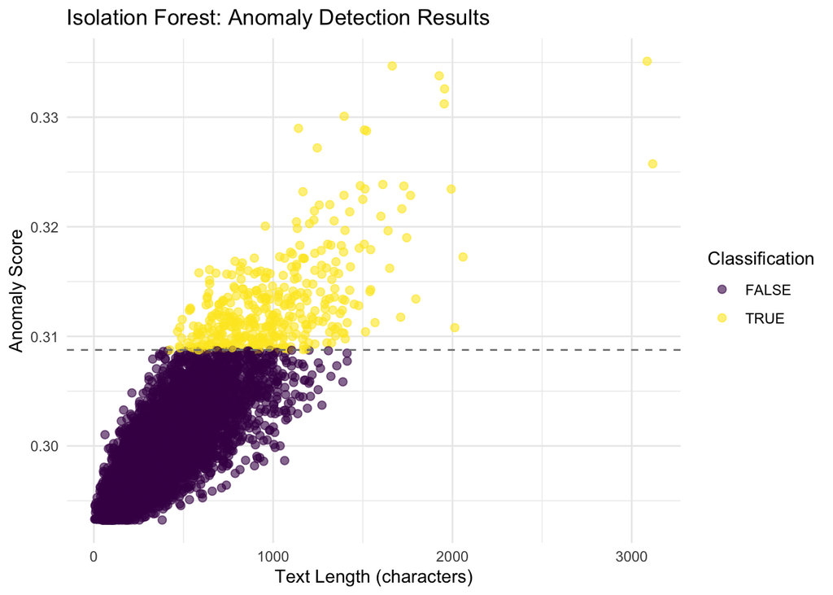

```r
# We create the plot of anomalies
ggplot(
  topic_df, aes(x = text_length, y = iso_score, color = iso_outlier)) +
  geom_point(alpha = 0.6, size = 2) +
  geom_hline(yintercept = threshold, linetype = "dashed", color = "gray50") +
  scale_color_viridis_d(alpha = 0.7) +
  labs(
    title = "Isolation Forest: Anomaly Detection Results",
    x = "Text Length (characters)",
    y = "Anomaly Score",
    color = "Classification"
  ) +
  theme_minimal()
```

As a next step we can now examine what makes these 387 anomalous, which topics do they belong to? What’s in their text? But before that, we need to understand what makes notes “anomalous”? We assume that it could be:

- Uses rare/unusual words are not seen in other documents much
- Very short or very long compared to others
- Written in a different style (more casual? more legal?)

We start by looking at the actual text of the departure notes and comparing our identified ‘anomalies’ with regular notes. To understand what makes certain CEO departures anomalous, we examine the top 10 most unusual narratives identified by Isolation Forest and compare them with the 10 most typical departures.

```r
# Get the most anomalous departures
top_anomalies <- topic_df |>
  arrange(desc(iso_score)) |>
  select(coname, fyear, departure_type, dominant_topic, iso_score, notes, text_length) |>
  head(10)

# Get some NORMAL departures for comparison
normal_examples <- topic_df |>
  filter(!iso_outlier) |>
  arrange(iso_score) |>  # Most "normal"
  select(coname, fyear, departure_type, dominant_topic, iso_score, notes, text_length) |>
  head(10)

# We can compare them, lets start with text length

cat("Anomalous documents text lengths:", top_anomalies$text_length)
```

```
Anomalous documents text lengths: 3086 1664 1926 1956 1954 1396 1141 1509 1521 1246
```

```r
cat("\nNormal documents text lengths:", normal_examples$text_length, "\n")
```

```
Normal documents text lengths: 193 90 101 106 75 155 108 107 121 85
```

```r
# And also look at averages
cat("\nAnomalous meman", mean(top_anomalies$text_length))
```

```
Anomalous meman 1739.9
```

```r
cat("\nNormal mean", mean(normal_examples$text_length))
```

```
Normal mean 114.1
```

Next, we look at the notes themselves to compare them.

```r
# Print the notes from anomalous departures
for(i in 1:3) {
  cat("ANOMALY", i, " - ", top_anomalies$coname[i], "\n")
  cat(substr(top_anomalies$notes[i], 1, 800), "...\n\n")
}
```

```
ANOMALY 1  -  WILMINGTON TRUST CORP
Mr. Cecala's retirement as Chairman and CEO of Wilmington Trust Corp. wasn't what he claimed it to be. Unbeknownst to the public, Wilmington Trust Corp. was concealing its dire financial portfolio from the eyes of investors. It did this through understating the amount owed on matured past-due loans …

ANOMALY 2  -  BED BATH & BEYOND INC
Bed Bath & Beyond announced Monday that CEO Steven Temares is stepping down, “effectively immediately,” as activist investors push for changes at the retailer.
 It said Mary Winston, who was recently named to the board, will serve as interim CEO until a replacement is found. The company said Temares is also resigning from Bed Bath & Beyond’s board.
 Winston has held various roles in retail, including serving as CFO at Family Dollar Stores. She also was CFO at Scholastic, and she’s currently president at WinsCo Enterprises, a financial and board governance consulting firm, in addition to being a board member at Acuity Brands, Domtar and Dover.
 Bed Bath & Beyond shares jumped more than 3% in premarket trading following the news but were last down more than 6%. The stock has gained nearly ...

ANOMALY 3  -  FINISH LINE INC -CL A
The Company announced on January 7, 2016 that Mr. Samuel Sato will succeed Mr. Glenn Lyon as Chief Executive Officer of the Company effective
 February 28, 2016. Mr. Sato currently serves as the Company’s President and is a member of the Board of Directors. Mr. Sato formerly served the Company as
 President, Finish Line Brand, President and Chief Merchandising Officer, and Executive Vice President, Chief Merchandising Officer. In connection with Mr.
 Sato’s appointment as CEO, the Company and Mr. Sato entered into an Employment Agreement, a copy of which is attached to this Form 8-K as Exhibit 99.1.
 Employment; Term. Executive and the Company agree that if Executive is employed by the Company on February 28, 2016 (the “Effective
 Date”), then the Employment Agreement is automatically term ...
```

```r
for(i in 1:3) {
  cat("NORMAL",  i, " - ", normal_examples$coname[i], "\n")
  cat(normal_examples$notes[i], "\n\n")
}
```

```
NORMAL 1  -  ASARCO INC
NEW YORK, N.Y., APRIL 28, 1999 -- Richard de J. Osborne, 65, retired today as chairman and chief executive officer of ASARCO Incorporated (NYSE: AR) after 25 years of service with the company.

NORMAL 2  -  GREAT LAKES CHEMICAL CORP
In April 1998, Mr. Bulriss replaced Mr. McDonald as president and chief executive officer.

NORMAL 3  -  NAVISTAR INTERNATIONAL CORP
Mr. Cotting retired as Chief Executive Officer on March 31,
1995 with 16.3 years of credited service.
```

The most anomalous narratives depicted above show a clear pattern: anomalies are characterized by extensive, detailed explanations rather than brief announcements.

The top 10 anomalous departures average 1739.9 characters, while typical departures average only 114.1 characters. Wilmington Trust’s departure note details financial fraud, and regulatory investigations. Bed Bath & Beyond’s note explains activist investor pressure and immediate CEO removal. These lengthy narratives suggest companies write more when circumstances are complicated, fraud requires explanation, activist pressure needs context.

In contrast, normal departures are brief and formulaic. These short announcements follow templates, state the fact and move on.

This pattern shows that text length might signal departure complexity. Straightforward retirements and routine successions use minimal language because no explanation is needed. Departures involving fraud, activist pressure, or other circumstances require longer narratives to justify decisions or provide context. Isolation Forest identifies these lengthy, detailed notes as anomalous because they deviate from the brief announcements that dominate the dataset.

We can also consider how many anomalies are in notes from each of the departure codes.

```r
# We look at the anomalies across the departure codess
topic_df |>
  count(departure_code, departure_type, iso_outlier) |>
  group_by(departure_code) |>
  filter(iso_outlier == TRUE) |>
  arrange(desc(n))
```

```
# A tibble: 7 × 4
# Groups:   departure_code [7]
  departure_code departure_type   iso_outlier     n
           <dbl> <chr>            <lgl>       <int>
1              7 Other            TRUE          143
2              5 Retired          TRUE          116
3              3 Job performance  TRUE          108
4              2 Illness          TRUE            6
5              4 Legal violations TRUE            6
6              9 No Reason        TRUE            5
7              6 New Opportunity  TRUE            3
```

Looking at departure types, “Other” - Code 7 and “Retire” - Code 5 categories show the highest number of anomalies rates, while “Death” - Code 1 does not have any anomalies. This aligns with our finding: retirements represent a huge amount of ceo departures, it would make sense for it to include many anomalies. Unusual circumstances under “Other” might require more explanations, and thus have longer texts and be considered as anomalies.

We can also look into how our identified anomalies are distributed across 6 topics identified through LDA.

```r
# We look at how anomalies are distributed across the 6 topics
topic_df |>
  count(dominant_topic, iso_outlier) |>
  group_by(dominant_topic) |>
  mutate(
    total = sum(n),
    prop_anomalous = n / total
  ) |>
  filter(iso_outlier == TRUE) |>
  arrange(desc(prop_anomalous))
```

```
# A tibble: 6 × 5
# Groups:   dominant_topic [6]
  dominant_topic iso_outlier     n total prop_anomalous
           <int> <lgl>       <int> <int>          <dbl>
1              5 TRUE           99  1101         0.0899
2              1 TRUE           84  1114         0.0754
3              3 TRUE          101  1488         0.0679
4              2 TRUE           51  1402         0.0364
5              6 TRUE           33  1132         0.0292
6              4 TRUE           19  1487         0.0128
```

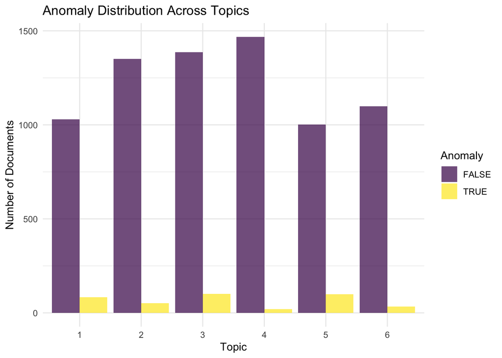

```r
# And visualise it for stakeholders
topic_df |>
  count(dominant_topic, iso_outlier) |>
  group_by(dominant_topic) |>
  mutate(prop = n / sum(n)) |>
  ggplot(aes(x = factor(dominant_topic), y = n, fill = iso_outlier)) +
  geom_col(position = "dodge") +
  scale_fill_viridis_d(alpha = 0.7) +
  labs(
    title = "Anomaly Distribution Across Topics",
    x = "Topic",
    y = "Number of Documents",
    fill = "Anomaly"
  ) +
  theme_minimal()
```

The visualisation shows us that anomaly rates vary substantially by topic, suggesting certain departure circumstances produce more unusual narratives than others.

**Topics with highest anomaly rates:**

- Topic 5 (M&A): 8.9% anomalous - the highest rate across all topics
- Topic 1 (Performance-Driven Departures): 7.5% anomalous
- Topic 3 (More Ambiguous Resignations): 6.7% anomalous

**Topics with lowest anomaly rates:**

- Topic 4 (Founder Transitions): 1.2% anomalous

This pattern makes sense given what we observed about narrative length and detail. Mergers and acquisitions (Topic 5) might involve complex financial transactions requiring extensive explanations of deal terms, and shareholder agreements, hence the high anomaly rate. Similarly, resignations and performance issues (Topic 1) often need justification, leading to longer, more detailed notes.

In contrast, planned retirements from founder transitions (Topic 4) might follow highly standardized templates. When a CEO retires after a long run with smooth succession planning, companies might use more brief, formulaic announcements.

These anomaly findings demonstrates an important relationship between our two methods: LDA identified which departure types exist (the six topics), while Isolation Forest reveals which types are most variable. Retirements are both common (largest topic) and has anomalies, while M&A departures are less common but highly variable in how they’re communicated.

### Comparing What Similarity and Anomaly Detection Show Us

Using LDA to find similar documents and Isolation Forest to find unusual ones gives us two different views of the same data. Each method sees things the other misses, and comparing them helps us understand CEO departure communication more fully.

**What similarity analysis can see that anomaly detection cannot**

LDA groups departures by shared vocabulary and themes, showing us the underlying structure of corporate communication. It revealed that most departures follow one of six recognizable patterns: M&A transactions, board succession announcements, ambiguous resignations, founder transitions, performance-driven exits, and career biography formats. This thematic view helps us understand what types of departures exist.

However, LDA treats all documents assigned to the same topic as similar, even if some are much more detailed than others. For example, a brief two-sentence M&A announcement and a 3,000-character explanation of merger terms might both land in Topic 5. LDA sees them as similar because they share M&A vocabulary, but they’re quite different in how much they reveal.

**What anomaly detection can see that similarity analysis cannot**

Isolation Forest looks at the overall feature patterns of each document, identifying departures that use unusual combinations of words or unusual amounts of detail. It found that anomalies tend to be much longer (averaging 1,740 characters versus 114 for typical departures) and often involve complex circumstances like fraud or regulatory investigations.

However, Isolation Forest doesn’t tell us why these documents are unusual or what they’re about. It flags the Wilmington Trust departure as anomalous because of its length and rare vocabulary, but it doesn’t recognize that this is an M&A-related departure involving financial fraud. The method sees statistical unusualness without understanding thematic content.

**What we learn by using both together**

Combining these perspectives suggests that CEO departure communication operates on two levels. At the broad level, companies seem to choose from a set of recognizable narrative styles based on their circumstances. A merger triggers M&A language; a long-serving founder stepping down introduces transition language. This is what LDA captures.

Within each style, companies then decide how much detail to provide. Most use more brief, standardized language. But some circumstances, perhaps involving controversy, complexity, or legal concerns, require companies to write much more. This variation within styles is what Isolation Forest captures.

The interaction between the two methods is also informative. We found that Topic 5 (M&A) has the highest anomaly rate (8.9%) while Topic 4 (Founder Transitions) has the lowest (1.2%). This suggests that some departure types are inherently more variable than others. Mergers involve complex transactions that sometimes require extensive explanation; planned retirements are more predictable and can follow standard scripts.

**What this comparison teaches us about the social world**

Our findings show us how corporate communication might balance standardization with situation-specific needs. Companies appear to rely on templates, which makes sense because well-executed templates signal professionalism. But when circumstances are complex or controversial, some companies break from the established style by providing much more detail.

For someone reading a CEO departure announcement, these two perspectives might be useful. The general template tells you what broad type of departure occurred. The level of detail might signal whether there’s more to the story. A brief M&A note suggests a straightforward transaction; an unusually long one might indicate complications worth investigating.

## Part B: Research Question

In selecting the dataset to work with, I was drawn to the CEO departures dataset because it includes both curious numeric data and text. Specifically, I would appreciate working with the data that spans multiple decades, as the prominent limitation of the dataset from W8 summative was the fact that it was one entry per person. Our CEO dataset contains text notes and metadata on CEO departures from 1987 to 2020.

This 33-year span is valuable because it captures major events in corporate governance history. The dataset includes the 2008 financial crisis and the more recent period of increased corporate transparency. Coming from Estonia, where corporate governance rules changed significantly after 1991 independence and later joining the EU, I was curious whether similar external pressures shaped how American companies communicate about CEO departures. The 2008 crisis seemed particularly interesting to examine because it was such a major economic shock, I wondered if companies changed how they announced CEO exits during that difficult period compared to normal times.

### Question

**Our main question is:** Do CEO departure narratives fundamentally change during economic crises compared to normal times? Specifically, we investigate whether CEO departures are described differently during the 2008-2009 financial crisis compared to stable economic periods.

### Value for Stakeholders

This question might matter to multiple different groups:

**For boards:** When boards need to announce a CEO departure during a crisis, they face a tough choice, should they be completely transparent about problems or try to reassure stakeholders? By looking at what companies actually said during 2008-2009, we can see what communication approaches were common during the worst financial crisis in recent history. This might help future boards understand what’s typical during economic stress.

**For regulators:** If we find that crisis-period announcements use vaguer or more abstract language than normal ones, this could mean companies become less transparent exactly when investors and employees need clear information most. Regulators might use these patterns to evaluate whether disclosure quality drops during economic downturns.

### Approach

We use two methods chosen specifically for our dataset’s characteristics and research question.

**First, we use keyness analysis.** Our research question asks how crisis differs from normal, which is a comparative question. Keyness is designed precisely for this: comparing vocabulary between two groups. We chose it because our dataset has clear crisis/normal periods (2008-2009 versus 2003-2007, 2010-2014) and curious text notes that might use different language. For CEO departure announcements, which are carefully worded corporate communications, lexical choices matter significantly, meaning that whether companies say “recession” versus “personal reasons” reveals strategic communication decisions. Keyness helps us identify these specific word choices statistically.

**Second, we use BERTopic.** It discovers topics using document embeddings and clustering to find topics. This matters because BERTopic can capture semantic meaning, meaning words that mean similar things get grouped together even if they’re different words. We apply BERTopic to examine whether crisis and normal periods produce different thematic patterns.

**Then, we use clustering (k-means and k-medoids).** We needed a method that could test whether vocabulary differences translate into distinct communication patterns, but our text data presented challenges. CEO departure notes are sparse and high-dimensional (thousands of possible words, most appearing rarely). We decided to try k-means first, which uses mathematical centroids as cluster centers, but it failed on our data, assigning 90% of departures to one giant cluster. We then tried k-medoids (PAM), which uses actual departure narratives as cluster centers instead of mathematical averages. K-medoids worked much better, producing balanced clusters, showing that our sparse text data needs specific exampkes to use in clustering rather than centroid-based approaches. We chose clustering specifically because our research question asks if crisis creates fundamentally different narratives, if it does, crisis and normal departures should naturally separate into different groups. Additionally, our sample size imbalance (544 crisis versus 3,003 normal) made it important to try clustering each period separately, which only makes sense with a method flexible enough to work on different-sized subsets.

**These methods work together** at different levels of analysis: keyness examines individual words, BERTopic examines themes, and clustering examines document groupings. This multi-level approach helps us understand whether crisis may change surface vocabulary, underlying themes, or both.

### Why Unsupervised Learning

We could build a supervised classifier to predict whether a departure occurred during crisis or normal times, but this would only tell us whether the periods are different, which we already know. Our research question is exploratory: we want to discover what patterns exist in how departures are described and how these relate to economic context.

Unsupervised methods let us explore without imposing our assumptions. Keyness reveals which words distinguish the periods. BERTopic discovers thematic groupings based on semantic similarity rather than our predefined categories. Clustering finds natural groupings in the documents, potentially revealing patterns we wouldn’t have thought to look for. These insights happen by letting the data structure itself. The crisis/normal division is our starting point for investigation, not an outcome we’re trying to predict.

### Data Preparation

We decided to prepare our data by focusing on a shorter time period of 2003 to 2014, rather than using all 33 years in the dataset. We chose these years because they include the 2008-2009 financial crisis in the middle, with more stable periods before (2003-2007) and after (2010-2014) for comparison.

We made this choice for practical reasons. Using the full 1987-2020 timespan would mix many different economic periods: the dot-com bubble crash, various small recessions, recovery periods, making it hard to isolate the crisis effect we’re interested in. By focusing on 2003-2014, we can more clearly compare what happened right before, during, and right after the 2008-2009 crisis without other major economic events confusing the picture. This narrower window also gives us more balanced pre and post-crisis periods (5 years before, 2 crisis years, 5 years after) rather than comparing 2 crisis years against 31 of more normal years.

We acknowledge this means we’re not examining the full dataset or other economic downturns like the early 1990s recession or 2020 COVID impacts, but for answering our specific question about the 2008-2009 crisis, this focused timeframe seems to be appropriate.

```r
# We create crisis/normal period labels
ceo_analysis <- departures_clean |>
  filter(fyear >= 2003, fyear <= 2014) |> # Focus on our analysis period
  mutate(
    period = case_when(
      fyear %in% 2008:2009 ~ "crisis", # Financial crisis years
      TRUE ~ "normal" # Pre/post crisis (2003-2007, 2010-2014)
    )
  )

# We check the distribution of crisis vs normal
table(ceo_analysis$period)
```

```
crisis normal
   544   3003
```

As we can see, there are 544 text notes that represent CEO departures during the crisis, and 3003 notes that represent normal times.

Next, we will create the corpus.

```r
# We build the corpus
corpus_ceo <- ceo_analysis |>
  corpus(
    text_field = "notes",
    docvars = c("period", "coname", "exec_fullname", "fyear", "ceo_dismissal")
  )
```

Next, as a light preprocessing we will apply tokenization. In this case, we choose to remove numbers.

```r
# We do light preprocessing: remove URLs + punctuation
toks_ceo <- tokens(
  corpus_ceo,
  remove_punct = TRUE,
  remove_url = TRUE,
  remove_symbols = TRUE,
  remove_numbers = TRUE
)

# Create DFM
dfm_ceo <- dfm(toks_ceo)

# Check dimensions
dfm_ceo
```

```
Document-feature matrix of: 3,547 documents, 15,651 features (99.74% sparse) and 10 docvars.
       features
docs    howard b bernick today retired from his role of president
  text1      1 1       1     1       1    1   1    1  4         1
  text2      0 0       0     0       0    0   1    0  0         0
  text3      0 0       0     0       0    0   1    0  2         1
  text4      0 0       0     0       0    1   0    0  2         0
  text5      0 0       0     0       0    3   1    0  5         0
  text6      0 0       0     0       0    1   2    0  4         1
[ reached max_ndoc ... 3,541 more documents, reached max_nfeat ... 15,641 more features ]
```

We also implement slight trimming to remove very rare words. We decided to created two versions of our DFM with different trimming levels. For keyness analysis, we used lighter trimming `min_termfreq = 5, min_docfreq = 3` to preserve comprehensive vocabulary, including potentially distinctive but rare terms like ‘recession.’ For clustering, we trimmed more a little more `(min_termfreq = 10, min_docfreq = 5)`. This heavier trimming was necessary because high-dimensional sparse data might cause clustering algorithms to fail.

```r
# We trim DFM: remove very rare terms (appear in < 3 documents)
dfm_keyness<- dfm_trim(
  dfm_ceo,
  min_termfreq = 5, # Term must appear at least 5 times total
  min_docfreq = 3, # Term must appear in at least 3 documents
  docfreq_type = "count"
)

# Check reduced dimensions
dfm_keyness
```

```
Document-feature matrix of: 3,547 documents, 2,878 features (98.73% sparse) and 10 docvars.
       features
docs    howard b today retired from his role of president and
  text1      1 1     1       1    1   1    1  4         1   3
  text2      0 0     0       0    0   1    0  0         0   1
  text3      0 0     0       0    0   1    0  2         1   2
  text4      0 0     0       0    1   0    0  2         0   4
  text5      0 0     0       0    3   1    0  5         0   3
  text6      0 0     0       0    1   2    0  4         1   6
[ reached max_ndoc ... 3,541 more documents, reached max_nfeat ... 2,868 more features ]
```

```r
# For k-means: we create more aggressively trimmed version
dfm_clustering <- dfm_trim(
  dfm_ceo,
  min_termfreq = 10, # Term must appear at least 10 times total
  min_docfreq = 5,
  docfreq_type = "count"
)

dfm_clustering
```

```
Document-feature matrix of: 3,547 documents, 1,617 features (97.87% sparse) and 10 docvars.
       features
docs    b today retired from his role of president and chief
  text1 1     1       1    1   1    1  4         1   3     1
  text2 0     0       0    0   1    0  0         0   1     0
  text3 0     0       0    0   1    0  2         1   2     1
  text4 0     0       0    1   0    0  2         0   4     0
  text5 0     0       0    3   1    0  5         0   3     1
  text6 0     0       0    1   2    0  4         1   6     0
[ reached max_ndoc ... 3,541 more documents, reached max_nfeat ... 1,607 more features ]
```

### Keyness Analysis

We now move on to our keyness analysis. We use Log-likelihood Ratio as our dataset has

- extremely sparse text
- many rare words
- highly skewed word frequency distributions

```r
# W apply keyness: compare crisis vs normal periods
# target = TRUE means we're focusing on "crisis" as the target group
keyness_result <- textstat_keyness(
  dfm_keyness,
  target = docvars(dfm_keyness, "period") == "crisis",
   measure = "lr"
)
```

Now, we will visualize keyness.

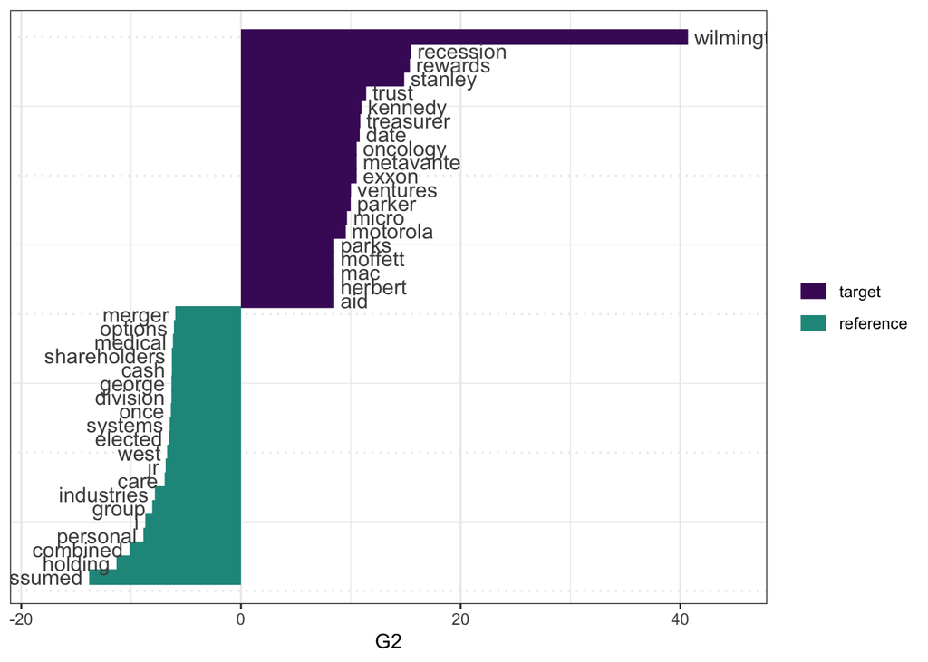

```r
textplot_keyness(keyness_result,
                 n = 20,
                 color = c("#481567FF", "#1F968BFF"))
```

And we can aslo extract top terms for crisis vs. non crisis notes.

```r
# We extract top crisis-associated terms
keyness_result |>
  slice_max(G2, n = 20)
```

```
      feature        G2            p n_target n_reference
1  wilmington 40.705777 1.769632e-10       15           2
2   recession 15.489049 8.298465e-05       14          15
3     rewards 15.379613 8.793191e-05        8           3
4     stanley 14.864303 1.155287e-04       12          11
5       trust 11.403242 7.331603e-04       16          28
6     kennedy 10.986237 9.179100e-04        9           8
7   treasurer 10.865484 9.797314e-04        7           4
8        date 10.818211 1.005065e-03       34          92
9       exxon 10.533875 1.172062e-03        5           1
10  metavante 10.533875 1.172062e-03        5           1
11   oncology 10.533875 1.172062e-03        5           1
12   ventures 10.016701 1.551271e-03       11          14
13     parker  9.992428 1.571852e-03        9           9
14      micro  9.655449 1.887908e-03        6           3
15   motorola  9.541053 2.009264e-03       10          12
16        aid  8.494236 3.562733e-03        5           2
17    herbert  8.494236 3.562733e-03        5           2
18        mac  8.494236 3.562733e-03        5           2
19    moffett  8.494236 3.562733e-03        5           2
20      parks  8.494236 3.562733e-03        5           2
21       save  8.494236 3.562733e-03        5           2
```

Keyness analysis shows us that strongest distinctive terms for crisis period are mostly company and executive names rather than general crisis vocabulary.

“Wilmington” appears in 15 crisis departures but only 2 normal ones. This might reflect Wilmington Trust Corporation’s multiple CEO changes during the financial crisis rather than being a word all companies used. Similarly, “exxon,” “motorola,” and “metavante” mark specific companies that experienced leadership changes during 2008-2009. Executive names like “kennedy,” “parker,” and “moffett” also appear as distinctive crisis terms.

Other crisis-associated terms like “rewards,” “treasury,” and “trust” might relate to compensation restructuring or financial services industry language during the downturn, though without examining specific examples we can’t be certain what drives these associations.

Next, we look at the top normal associated terms.

```r
# Extract top normal-associated terms
keyness_result |>
  slice_min(G2, n = 20)
```

```
        feature         G2            p n_target n_reference
1       assumed -13.818160 0.0002013804        0          41
2       holding -11.331710 0.0007619471        1          52
3      combined -10.141939 0.0014493362        1          48
4      personal  -8.889125 0.0028687421        5          86
5             i  -8.710341 0.0031641000        9         120
6         group  -8.082033 0.0044706273       24         230
7    industries  -7.835715 0.0051223895        4          72
8          care  -6.948822 0.0083874449        1          37
9            jr  -6.858566 0.0088217301        8         102
10         west  -6.719915 0.0095342149        0          30
11      elected  -6.555965 0.0104533154       11         124
12      systems  -6.489295 0.0108526001        8         100
13         once  -6.384365 0.0115129933        1          35
14     division  -6.330681 0.0118666762        2          46
15       george  -6.330681 0.0118666762        2          46
16         cash  -6.292333 0.0121261305       14         145
17 shareholders  -6.292333 0.0121261305       14         145
18      medical  -6.194173 0.0128171576        6          82
19      options  -6.104479 0.0134839713        1          34
20       merger  -5.976067 0.0145013077       48         374
```

In contrast, normal-period departures use more standardized corporate language. The top distinctive terms include ‘assumed’, ‘personal’, ‘elected’, and ‘shareholders’. These terms represent conventional succession narratives: executives ‘assume’ new roles, depart for ‘personal’ reasons, are ‘elected’ to positions, or transitions are framed around ‘shareholder’ interests. The term ‘merger’ suggests M&A activity might characterize normal-period departures more than crisis ones.

Executive names appear here too (“george,” “west”) but less than in crisis results. Terms like “medical” and “systems” might indicate certain industries (healthcare, technology) had more departures during normal periods than crisis.

Overall, this suggests that during crisis, a few specific companies experienced many departures, while during normal times, departures happened more broadly across many companies using more standard language.

Now, with these interesting findings we would like to see how these terms appear in context.

```r
# We find departures containing key crisis terms
# Mentioning "recession"
recession_examples <- ceo_analysis |>
  filter(fyear >= 2008, fyear <= 2009) |>
  filter(str_detect(notes, regex("recession", ignore_case = TRUE))) |>
  select(coname, exec_fullname, fyear, period, notes) |>
  head(3)

# View
recession_examples
```

```
# A tibble: 3 × 5
  coname                exec_fullname           fyear period notes
  <chr>                 <chr>                   <dbl> <chr>  <chr>
1 WILMINGTON TRUST CORP Ted Thomas Cecala        2009 crisis "Mr. Cecala's reti…
2 RYLAND GROUP INC      R. Chad Dreier           2008 crisis "A 27 Feb. 2009 W.…
3 PROLOGIS INC          Jeffrey Howard Schwartz  2008 crisis "he quit during th…
```

```r
# Print out notes
recession_examples$notes
```

```
[1] "Mr. Cecala's retirement as Chairman and CEO of Wilmington Trust Corp. wasn't what he claimed it to be. Unbeknownst to the public, Wilmington Trust Corp. was concealing its dire financial portfolio from the eyes of investors. It did this through understating the amount owed on matured past-due l…
[2] "A 27 Feb. 2009 W.S.J. article reveals the truth behind Mr. Dreier's so-called retirement as President, C.E.O., and Chairman of Ryland Group, Inc. on 29 May of the same year. Mr. Dreier opted to receive lump-sum payments of $27 million in two installments over the course of six months, rather th…
[3] "he quit during the economic recession in 2008, after company stock price went from 70 to 2"
```

The three crisis departures that explicitly mention “recession” show a common pattern: all use the recession to explain why the CEO had to leave.

These notes differ in length, one is over 3,000 characters detailing financial fraud and merger negotiations, another describes a $27 million buyout disguised as retirement, and the third simply states the CEO quit after stock dropped from 70 to 2. Despite these differences in detail level, all three frame the departure through external economic forces. The recession is presented as the direct cause of the company’s problems (concealed losses, housing market collapse, stock crashes) that made the CEO exit necessary. This seems to shift blame from internal management decisions to uncontrollable external circumstances.

```r
# Normal-period terms - "personal"
personal_examples <- ceo_analysis |>
  filter(fyear >= 2003, fyear <= 2014) |>
  filter(str_detect(notes, regex("personal", ignore_case = TRUE))) |>
  select(coname, exec_fullname, fyear, period, notes) |>
  head(3)

personal_examples
```

```
# A tibble: 3 × 5
  coname                       exec_fullname        fyear period notes
  <chr>                        <chr>                <dbl> <chr>  <chr>
1 ALBERTO-CULVER CO            Howard B. Bernick     2007 normal "Howard B. Ber…
2 AMERICAN INTERNATIONAL GROUP Maurice R. Greenberg  2004 normal "Fraud and acc…
3 SOUTHWEST AIRLINES           James F. Parker       2004 normal "The 57-year-o…
```

```r
personal_examples$notes
```

```
[1] "Howard B. Bernick, today retired from his role of President and Chief Executive Officer of Alberto-Culver.\n  Alberto-Culver has split into two separate publicly-traded companies: new Alberto-Culver, a worldwide manufacturer and marketer of leading personal care products, and Sally Beauty Holdi…
[2] "Fraud and accounting manipulations. Mr. Greenberg's move to leave the company, which he had run for four decades, was the latest development in a burgeoning investigation into AIG and the insurance industry. The transaction between the Berkshire unit, General Re, and AIG first drew scrutiny fro…
[3] "The 57-year-old chief executive of Southwest Airlines, James F. Parker, unexpectedly stepped down yesterday after just three years, citing personal reasons for leaving what he called a \"draining job.\" The move came hours after the low-cost airline reported that second- quarter profit fell 54%…
```

Normal-period departure examples seem to use very different language than crisis departures.

Alberto-Culver Co frames the exit around corporate restructuring (splitting into two companies). American International Group discusses internal fraud and regulatory investigations. Southwest talks about “personal reasons” despite 54% profit decline, explaining it through company-specific labor issues. None mention broader economic conditions or market forces.

The key diference is that crisis departures blame external economic forces (“recession caused the housing bubble burst”). Normal departures focus on individual choices (“personal reasons”), internal company problems (fraud), or company-specific events (corporate split). Even when normal-period companies have serious problems, they don’t mention the broader economy, they seem to keep the explanation internal to the company.

### Keyness: Key Finding

Keyness showed us that when crisis communication explicitly references economic conditions, it tends to externalize blame to macroeconomic forces, while normal communication internalizes explanations to individual or company factors. However, we should note that most crisis departures (97%) avoided naming the recession directly, so this externalizing pattern appears in only a small minority of cases. For those departures that do attribute CEO exits to forces beyond their control, this framing allows boards to explain away failures without fully acknowledging management responsibility. During normal times, companies seem more likely to frame departures through individual agency (“personal reasons”) or even acknowledge internal problems (fraud, restructuring).

However, we’re observing patterns in limited examples, only a small number of crisis departures explicitly mentioned recession, and individual company circumstances varied greatly. The keyness results show which words distinguish the periods statistically, but interpreting why companies chose these framing strategies requires caution.

Now, with k-means we will test whether linguistic patterns we found create systematically distinct narrative clusters.

### BERTopic: Topic Discovery

In Part A, we used LDA to identify what topics exist across CEO departure narratives. LDA works by finding words that frequently appear together, grouping them into topics. This bag-of-words approach was useful for identifying broad narrative categories like M&A announcements, retirement notices, and performance-related exits.

However, LDA has a limitation for our Part B research question. Because LDA treats each word as completely separate, it can’t recognize that “fired” and “terminated” mean similar things, or that “economic downturn” and “recession” refer to the same concept. If crisis and normal periods use different words to express similar ideas, LDA would see them as different topics even when they’re thematically identical.

BERTopic addresses this limitation through a fundamentally different approach. I learned that instead of counting words, BERTopic:

1. Embeds documents using neural language models that capture semantic meaning
2. Clusters similar documents based on their meaning, not just shared vocabulary
3. Extracts topic words from each cluster using a class-based TF-IDF procedure

This means BERTopic can detect whether crisis and normal departures discuss similar themes even if they use different vocabulary, exactly what we need given our keyness finding that the periods use different words.

We will apply BERTopic to all Part B documents (both crisis and normal) to discover what semantic themes exist.

It is important to note that we made some decisions when configuring BERTopic for our data. First, we chose to use smaller batch sizes (batch_size = 16L) due to memory constraints, which made the embedding process slower but more stable.

For the clustering component, we selected HDBSCAN with `min_cluster_size = 50L`, meaning each topic must contain at least 50 documents to be considered a valid cluster. We chose 50 because it felt like a reasonable middle ground: setting it lower (like 30) might create topics based on just a few unusual documents, while setting it higher (like 100) might merge different themes together. With around 3,500 documents in our subset of the dataset, 50 seemed small enough to find distinct patterns but large enough that each topic would have enough examples.

```r
# We create function to run BERTopic
run_bertopic <- function(texts) {
   # Import necessary Python modules
  bertopic <- import("bertopic")
  sentence_transformers <- import("sentence_transformers")
  hdbscan <- import("hdbscan")

  # Import UMAP through sklearn's manifold or directly
  umap_module <- reticulate::import("umap", convert = FALSE)

  SentenceTransformer <- sentence_transformers$SentenceTransformer
  embedding_model <- SentenceTransformer("BAAI/bge-m3")

  embeddings <- embedding_model$encode(
    texts,
    show_progress_bar = TRUE,
    batch_size = 16L
  )

  # UMAP with random seed for reproducibility
  umap_model <- umap_module$UMAP(
    n_neighbors = 15L,
    n_components = 5L,
    min_dist = 0.0,
    metric = "cosine",
    random_state = 33L
  )

   # HDBSCAN settings
  hdbscan_model <- hdbscan$HDBSCAN(
    min_cluster_size = 50L,
    min_samples = 5L,
    metric = "euclidean",
    cluster_selection_method = "eom",
    prediction_data = TRUE
  )

  topic_model <- bertopic$BERTopic(
    embedding_model = embedding_model,
    umap_model = umap_model,
    hdbscan_model = hdbscan_model,
    calculate_probabilities = TRUE
  )

  fit_transform <- topic_model$fit_transform(texts, embeddings)
  topics <- fit_transform[[1]]
  probs <- fit_transform[[2]]


  return(list(model = topic_model, topics = topics, probs = probs))
}

# Prepare texts for BERTopic
bertopic_texts <- ceo_analysis$notes

# Run BERTopic on our Part B data
cat("Running BERTopic on", length(bertopic_texts), "documents...\n")
```

```
Running BERTopic on 3547 documents...
```

```r
bertopic_result <- run_bertopic(bertopic_texts)

# Extract results
topic_model <- bertopic_result$model
bertopic_topics <- bertopic_result$topics
bertopic_probs <- bertopic_result$probs

cat("BERTopic complete.\n")
```

```
BERTopic complete.
```

Now that we sucessfully ran our BERTopic, we can look at the summary.

```r
# Get topic information
topic_info <- topic_model$get_topic_info()

# View topic summary
cat("Number of topics found:", nrow(topic_info) - 1, "(excluding outlier topic -1)\n")
```

```
Number of topics found: 11 (excluding outlier topic -1)
```

```r
cat("Number of outlier documents:", topic_info$Count[topic_info$Topic == -1], "\n\n")
```

```
Number of outlier documents: 1452
```

```r
# Display topic info
topic_info |>
  select(Topic, Count, Name) |>
  head(15)
```

```
   Topic Count                           Name
1     -1  1452               -1_the_of_and_in
2      0   643              0_of_the_and_will
3      1   403           1_the_was_to_company
4      2   174               2_the_to_code_of
5      3   164            3_of_the_merger_and
6      4   151 4_down_voluntarily_ceo_stepped
7      5   132                5_the_he_as_for
8      6   124        6_his_retirement_the_he
9      7   121           7_served_and_from_of
10     8    67      8_was_acquired_by_company
11     9    59       9_as_retired_chairman_he
12    10    57                10_the_mr_of_to
```

Looking at the results, it is important to acknowledge that approximately 40% of documents were classified as outliers (topic -1), meaning they didn’t fit neatly into any cluster. This is higher than ideal, but it reflects the reality that CEO departure notes often share very similar language which might make differentiation difficult. For our analysis, we focus on the remaining documents that were assigned to topics, while also examining whether the outlier rate differs between crisis and normal periods.

Next, let’s look at the words that are representative of each topic.

```r
# Get topic representations in a more readable format
topic_representations <- map(
  topic_model$get_topic_info()$Representation,
  ~ paste(.x, collapse = ", ")
)

# Print the topics
for (i in 1:min(15, length(topic_representations))) {
  cat("Topic", i - 1, ":", topic_representations[[i]], "\n")
}
```

```
Topic 0 : the, of, and, in, to, as, company, was, ceo, he
Topic 1 : of, the, and, will, executive, chief, as, officer, board, president
Topic 2 : the, was, to, company, in, of, and, that, ceo, for
Topic 3 : the, to, code, of, changed, and, company, in, as, was
Topic 4 : of, the, merger, and, acquisition, inc, in, agreement, to, stock
Topic 5 : down, voluntarily, ceo, stepped, after, to, his, steps, as, from
Topic 6 : the, he, as, for, ceo, years, remained, chairman, of, his
Topic 7 : his, retirement, the, he, to, mr, of, in, was, retire
Topic 8 : served, and, from, of, since, as, mr, officer, executive, chief
Topic 9 : was, acquired, by, company, merger, the, ceo, he, and, this
Topic 10 : as, retired, chairman, he, of, from, in, the, executive, board
Topic 11 : the, mr, of, to, was, in, and, company, for, his
```

BERTopic identified 11 topics in our corpus. Looking at the representative words, we can attempt to interpret what each topic captures, though we should note that many topics share similar vocabulary given the formulaic nature of CEO departure announcements.

[output not shown]

Let’s now move on to answering our research question specifically with the topics.

```r
# We add BERTopic results to our analysis dataframe
ceo_bertopic <- ceo_analysis |>
  mutate(
    bertopic_topic = bertopic_topics,
    bertopic_prob = apply(bertopic_probs, 1, max)
  )

# We also need to verify the alignment
if(nrow(ceo_bertopic) != length(bertopic_topics)) {
  stop("ERROR: Row count mismatch")
}
```

We will consider how topics are distributed across crisis and normal periods.

```r
# We compare topic distribution by period
topic_by_period <- ceo_bertopic |>
  filter(bertopic_topic != -1) |>  # We decided to exclude outliers for cleaner comparison
  count(period, bertopic_topic) |>
  group_by(period) |>
  mutate(proportion = n / sum(n)) |>
  ungroup()

# Calculate overall topic sizes for reference
topic_sizes <- ceo_bertopic |>
  filter(bertopic_topic != -1) |>
  count(bertopic_topic, name = "total") |>
  arrange(desc(total))

# Now we show top topics by period
topic_by_period |>
  pivot_wider(
    names_from = period,
    values_from = c(n, proportion),
    values_fill = list(n = 0, proportion = 0)
  ) |>
  arrange(desc(n_crisis + n_normal)) |>
  head(10)
```

```
# A tibble: 10 × 5
   bertopic_topic n_crisis n_normal proportion_crisis proportion_normal
            <int>    <int>    <int>             <dbl>             <dbl>
 1              0       96      547            0.307             0.307
 2              1       75      328            0.240             0.184
 3              2       20      154            0.0639            0.0864
 4              3       17      147            0.0543            0.0825
 5              4       26      125            0.0831            0.0701
 6              5       26      106            0.0831            0.0595
 7              6       10      114            0.0319            0.0640
 8              7       18      103            0.0575            0.0578
 9              8        9       58            0.0288            0.0325
10              9        8       51            0.0256            0.0286
```

We can also visualize the results for easier comparison.

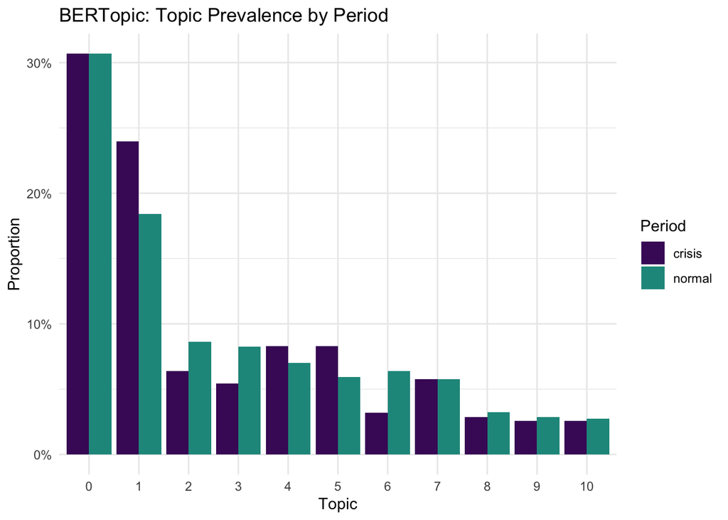

```r
# We visualize topic prevalence by period
topic_by_period |>
  ggplot(aes(x = factor(bertopic_topic), y = proportion, fill = period)) +
  geom_col(position = "dodge") +
  scale_fill_manual(values = c("crisis" = "#481567FF", "normal" = "#1F968BFF")) +
  scale_y_continuous(labels = scales::percent) +
  labs(
    title = "BERTopic: Topic Prevalence by Period",
    x = "Topic",
    y = "Proportion",
    fill = "Period"
  ) +
  theme_minimal()
```

Though, we should be careful with these interpretations. The crisis sample is much smaller than the normal period (544 vs 3,003), so the crisis proportions may be less reliable and small percentage differences (e.g., 24% vs 18%) may not be as meaningful given the sampling variability.

Now, let’s look at the notes from these different topics. We will calculate which topics differ most in prevalence between crisis and normal periods and look at the specific text note examples.

```r
# We calculate which topics are most different between periods
topic_differences <- topic_by_period |>
  filter(bertopic_topic > 0) |>
  select(period, bertopic_topic, proportion) |>
  pivot_wider(names_from = period, values_from = proportion, values_fill = 0) |>
  mutate(
    difference = crisis - normal,
    abs_difference = abs(difference)
  ) |>
  arrange(desc(abs_difference))

# Next, we dentify crisis-heavy and normal-heavy topics
crisis_heavy_topics <- topic_differences |>
  filter(difference > 0) |>
  head(2) |>
  pull(bertopic_topic)

normal_heavy_topics <- topic_differences |>
  filter(difference < 0) |>
  head(2) |>
  pull(bertopic_topic)

# Print example documents from crisis-heavy topics
cat("=== Example Documents from Crisis-Heavy Topics ===\n")
```

```
=== Example Documents from Crisis-Heavy Topics ===
```

```r
for(topic in crisis_heavy_topics) {
  cat("\n--- Topic", topic, "---\n")
  examples <- ceo_bertopic |>
    filter(bertopic_topic == topic, period == "crisis") |>
    slice_head(n = 2)
  for(i in 1:nrow(examples)) {
    cat("\n", examples$coname[i], "(", examples$fyear[i], "):\n")
    cat(str_trunc(examples$notes[i], 500), "\n")
  }
}
```

```
--- Topic 1 ---

 GENERAL MOTORS CO ( 2009 ):
Wagoner resigned as chairman and CEO at General Motors on March 29, 2009, at the request of the White House. The latter part of Wagoner's tenure as CEO of General Motors found him under heavy criticism as the market valuation of GM went down by more than 90% and the company lost more than US$82 bill…

 DATASCOPE CORP ( 2008 ):
In the letter, Ramius highlights concerns about six separate reports of ethics   violations by Mr. Lawrence Saper, the Company's founder, Chairman and CEO, and a   senior executive in Europe. Additionally, the letter raises further concerns   over a lack of management stability at Datascope demonstr…

--- Topic 5 ---

 BALDOR ELECTRIC CO ( 2009 ):
CEO stepped down after 40 years with the company and stayed on as the Chairman to assist the board with the new CEO's transition

 PANERA BREAD CO ( 2009 ):
After serving as Panera Bread’s CEO for 26 years, co-founder Ronald Shaich resigned in January. Although he still remains the company’s chairman, Shaich reflects on what he wishes he did differently as CEO
```

```r
# Print example documents from normal-heavy topics
cat("\n=== Example Documents from Normal-Heavy Topics ===\n")
```

```
=== Example Documents from Normal-Heavy Topics ===
```

```r
for(topic in normal_heavy_topics) {
  cat("\n--- Topic", topic, "---\n")
  examples <- ceo_bertopic |>
    filter(bertopic_topic == topic, period == "normal") |>
    slice_head(n = 2)
  for(i in 1:nrow(examples)) {
    cat("\n", examples$coname[i], "(", examples$fyear[i], "):\n")
    cat(str_trunc(examples$notes[i], 500), "\n")
  }
}
```

```
--- Topic 6 ---

 PROGRESS ENERGY INC ( 2003 ):
William Cavanaugh originally wanted to retire in Feb, 2004. Due to industry turmoil, the board asked him to hold on to his retirement decision in Sep, 2002. The situation has improved since then which has allowed him to finalize his retirement plans.

 COLGATE-PALMOLIVE CO ( 2007 ):
Mr. Mark will remain chairman for up to 18 months after he retires as CEO, the company said. The succession plans were being worked out since the previous one year.

--- Topic 3 ---

 BAUSCH & LOMB HLDGS -REDH ( 2006 ):
ROCHESTER, N.Y., October 26, 2007 — Bausch & Lomb (NYSE: BOL) and Warburg Pincus, the global private equity firm, announced today that affiliates of Warburg Pincus have completed the acquisition of Bausch & Lomb for a total purchase price of approximately $4.5 billion, including approximately $830 m…

 MEADWESTVACO CORP ( 2014 ):
NORCROSS, Ga., July 1, 2015 (GLOBE NEWSWIRE) -- WestRock Company (NYSE:WRK) today announced that it has begun operations following the completion of the combination of MeadWestvaco Corporation and Rock-Tenn Company.
```

In contrast, the more ‘normal’ leaning topics contain more routine transitions. Topic 6 shows planned retirements where CEOs finalise departure plans after industry conditions improve, or where succession has been carefully worked out over a year. Topic 3 captures M&A-related departures where companies were acquired by private equity firms or merged with other companies.

**BERTopic Findings**

Looking at example documents, crisis-heavy topics tend to contain departures involving external pressure or difficult circumstances. Normal-heavy topics tend to feature more routine transitions with planned successions. However, the differences are modest (all under 6 percentage points), and the same topics appear in both periods.

### K-means Clustering

So far, keyness has shown us that crisis and normal periods use different vocabulary, and BERTopic has revealed some differences in thematic emphasis. We now turn to clustering to examine whether these differences are strong enough for documents to naturally group by period, or whether crisis and normal departures are mixed together.

First, we apply TF-IDF to our text data, as it downweights common terms and upweights distinctive ones. Then, we convert our data into a matrix.

```r
# Apply TF-IDF
dfm_tfidf_result <- dfm_tfidf(dfm_clustering, scheme_tf = "prop")
```

We apply LSA for the dimensionality reduction. We decided to use LSA because clustering doesn’t work really well with too many dimensions, when there are too many features, everything might look equally far apart and patterns might disappear. LSA helps by finding the main patterns in how words appear together and summarizing them in fewer dimensions. We chose 10 dimensions based on Week 11 recommendations for clustering tasks.

```r
# We apply LSA to reduce dimensions
lsa_result <- textmodel_lsa(
  dfm_tfidf_result,
  nd = 10
)

# We extract document coordinates in LSA space
lsa_docs <- lsa_result$docs
```

Now, before we conduct k-means clustering, we need to find the best k. For that, we will use elbow and silhouette plots.

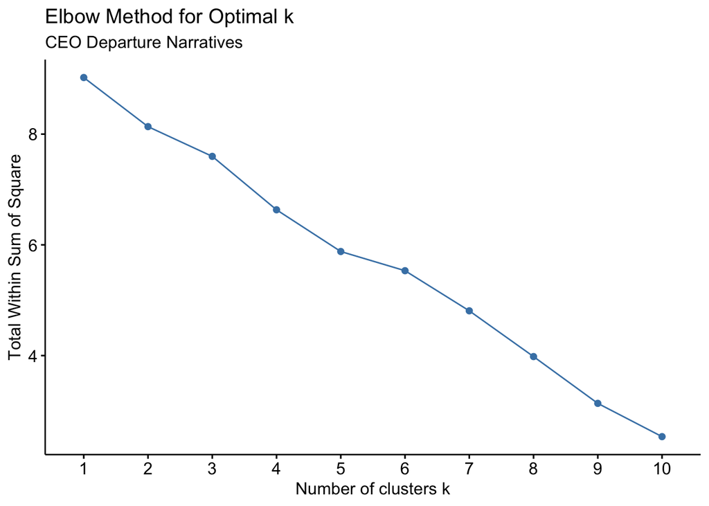

```r
# We apply elbow method
fviz_nbclust(
  lsa_docs,
  kmeans,
  method = "wss",
  k.max = 10
) +
  labs(
    title = "Elbow Method for Optimal k",
    subtitle = "CEO Departure Narratives"
  )
```

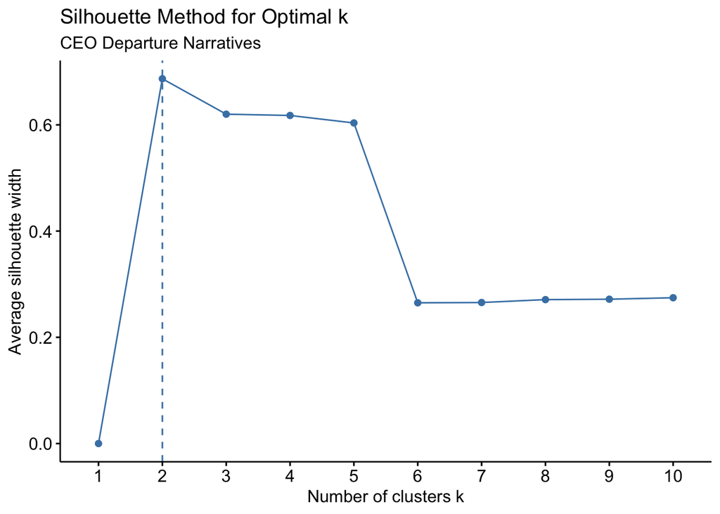

```r
# We also apply silhouette method for optimal k
fviz_nbclust(
  lsa_docs,
  kmeans,
  method = "silhouette",
  k.max = 10
) +
  labs(
    title = "Silhouette Method for Optimal k",
    subtitle = "CEO Departure Narratives"
  )
```

```r
# We run k-means clustering
set.seed(2025)

kmeans_result <- kmeans(
  lsa_docs,
  centers = 4,
  nstart = 25,
  iter.max = 100
)

# Check cluster sizes
kmeans_result$size
```

```
[1]  326    1    7 3213
```

```r
# Add to dataframe to compare
ceo_kmeans <- ceo_analysis |>
  mutate(cluster_kmeans = kmeans_result$cluster)

# We also want to verify alingment just in case
if(nrow(ceo_kmeans) != length(kmeans_result$cluster)) {
  stop("ERROR: Row count mismatch!")
}

# Now we are interested in hwo data clustered in regards to period: crisis/normal
kmeans_comp <- table(ceo_kmeans$cluster_kmeans, ceo_kmeans$period)
print(kmeans_comp)
```

```
    crisis normal
  1     61    265
  2      0      1
  3      2      5
  4    481   2732
```

Looking at how crisis versus normal departures distributed across these clusters shows an interesting pattern. The giant Cluster 4 contained 481 crisis and 2,732 normal departures, maintaining roughly the same 15% crisis proportion as the overall dataset. Cluster 1 had 61 crisis and 265 normal (about 19% crisis). The tiny clusters (2 and 3) had almost no departures. This distribution suggests that crisis and normal departures don’t seem to naturally separate into different groups based on their text patterns.

However, the severe imbalance in cluster sizes also might indicate that k-means couldn’t work well with our sparse text data, which is why we tried k-medoids next.

### K-medoids Clustering

Now, to test whether the clustering failure was method-specific rather than data-inherent, we decided to apply PAM (k-medoids clustering), which uses actual documents as cluster centers instead of mathematical centroids.

We start by determining an optimal k for PAM, again by using elbow and silhouette methods.

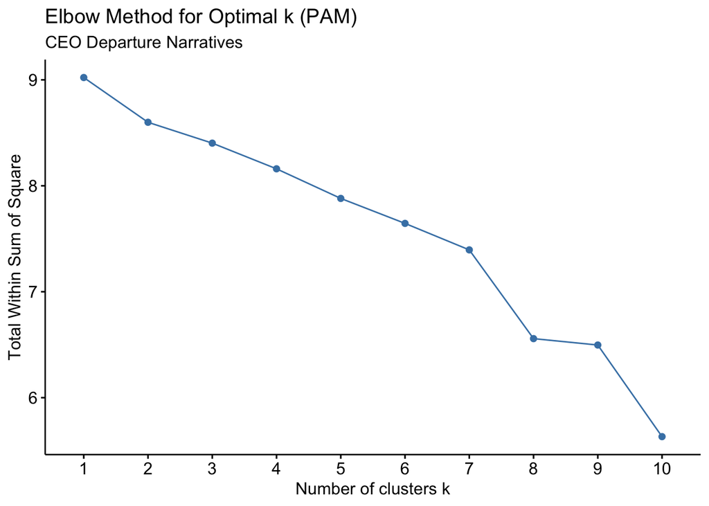

```r
# We apply elbow method for PAM
fviz_nbclust(
  lsa_docs, # Same 10-dimensional LSA space
  pam, # Using PAM instead of kmeans
  method = "wss",
  k.max = 10
) +
  labs(
    title = "Elbow Method for Optimal k (PAM)",
    subtitle = "CEO Departure Narratives"
  )
```

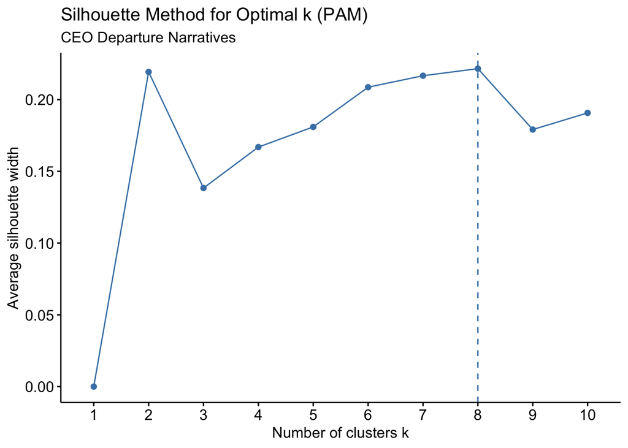

```r
# Silhouette method for PAM
fviz_nbclust(
  lsa_docs,
  pam,
  method = "silhouette",
  k.max = 10
) +
  labs(
    title = "Silhouette Method for Optimal k (PAM)",
    subtitle = "CEO Departure Narratives"
  )
```

The PAM optimization plots suggested some detectable cluster structure. Silhouette analysis showed us k=8 had the highest score (about 0.23), with the elbow plot showing diminishing returns around k=7-8. We chose k=8 as our final clustering solution.

While the silhouette score of 0.23 indicates only modest cluster separation, meaning the boundaries between groups aren’t very clear, this was the best structure PAM could find in our data. The weak clustering overall suggests that CEO departure narratives, whether during crisis or normal times, might share considerable similarity in how they’re structured.

```r
# We run k-medoids clustering
pam_result <- pam(
  lsa_docs,
  k = 8,
  metric = "euclidean"
)

# Check cluster sizes
print(table(pam_result$clustering))
```

```
   1    2    3    4    5    6    7    8
1251  808  956  152  144   88  144    4
```

We can see that PAM clustering with k=8 identified eight narrative groups with varying sizes. The clusters range from very large (Cluster 1 with 1,251 departures, 35.3%) to very small (Cluster 8 with only 4 departures, 0.1%). The distribution shows three substantial clusters (Clusters 1, 3, and 2 with 1,251, 956, and 808 departures respectively), three medium-sized clusters (Clusters 4, 5, and 7 with around 140-150 departures each), one smaller cluster (Cluster 6 with 88 departures), and one tiny cluster (Cluster 8 with 4 departures).

This uneven distribution suggests that while PAM found eight patterns in the data, CEO departure narratives concentrate heavily in a few main types. The three largest clusters likely represent the most common communication templates companies use, while the smaller clusters might capture less frequent but distinct narrative styles.

```r
# Add to dataframe to compare
ceo_pam <- ceo_analysis |>
  mutate(cluster_pam = pam_result$clustering)

# We also want to verify alingment just in case
if(nrow(ceo_pam) != length(pam_result$clustering)) {
  stop("ERROR: Row count mismatch!")
}

# Now we are interested in hwo data clustered in regards to period: crisis/normal
table(ceo_pam$cluster_pam, ceo_pam$period)
```

```
    crisis normal
  1    189   1062
  2    126    682
  3    142    814
  4     30    122
  5     17    127
  6     13     75
  7     25    119
  8      2      2
```

When we cluster all departures together based on their text patterns, crisis and normal periods don’t separate into different clusters. Instead, they mix proportionally in every cluster. This suggests that the vocabulary differences keyness identified (crisis using “recession,” normal using “personal”) don’t create fundamentally different narrative types. Companies appear to use similar communication structures regardless of economic period, meaning that the eight clusters likely represent different departure circumstances (M&A, retirements, resignations) that occur in both crisis and normal times, just with different words substituted.

This finding hints that crisis doesn’t fundamentally change how companies structure departure announcements, but rather changes which specific words they use within similar structures.

To visualize our cluster structure, we decided to project the 10-dimensional LSA space onto 2 dimensions using UMAP, a non-linear dimensionality reduction technique covered in Week 8. Unlike linear projections (e.g., showing only LSA Dimensions 1-2), UMAP preserves local neighborhood structure and often reveals cluster boundaries more clearly.

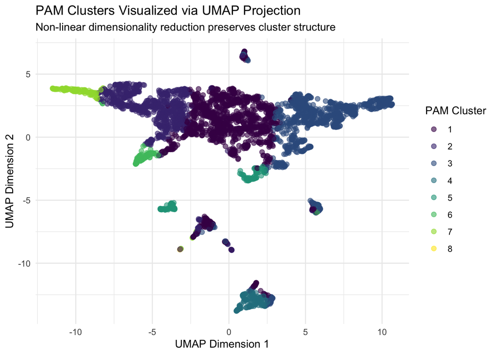

```r
# We will UMAP for visualization only

# Apply UMAP to 10D LSA coordinates
umap_coords <- umap(
  lsa_docs,
  n_neighbors = 15,    # Controls local vs. global structure
  min_dist = 0.1,      # Minimum distance between points
  metric = "euclidean"
)

# Add to visualization dataframe
viz_data_umap <- ceo_pam |>
  mutate(
    UMAP1 = umap_coords[, 1],
    UMAP2 = umap_coords[, 2],
    cluster_label = factor(cluster_pam)
  )

# Plot
ggplot(viz_data_umap, aes(x = UMAP1, y = UMAP2, color = cluster_label)) +
  geom_point(alpha = 0.6, size = 2) +
  scale_color_viridis_d() +
  labs(
    title = "PAM Clusters Visualized via UMAP Projection",
    subtitle = "Non-linear dimensionality reduction preserves cluster structure",
    x = "UMAP Dimension 1",
    y = "UMAP Dimension 2",
    color = "PAM Cluster"
  ) +
  theme_minimal()
```

Let’s further examine our clusters by extracting the documents that are the centers.

```r
# We first get the 4 medoids (actual departure indices that are cluster centers)
medoid_indices <- pam_result$id.med

# Get the medoid documents
medoid_docs <- ceo_pam |>
  slice(medoid_indices) |>
  select(cluster_pam, coname, exec_fullname, fyear, period, notes)

# View the notes
medoid_docs$notes
```

```
[1] "3Com Corp. announced today that CEO Bruce Claflin will retire once a replacement is found. Once a new CEO is found, Claflin will act as a senior adviser for six months to whomever is hired to ensure a smooth transition. \n  \n  3Com sales have plummeted under Mr. Claflin's leadership, from $2.4…
[2] "Gregory decided to leave Kraton after being with the company for 3 years. Under his tenure he helped transform the compnay positively. He stayed with the company for some time in an advisory role and as a member of the board. He also resigned from his posirion on the board and as an execuitve o…
[3] "On December 19, 2014, Julio M. Quintana resigned effective immediately as President and Chief Executive Officer of Tesco Corporation (the \"Company\") in line with his intention previously announced by a press release issued on August 21, 2014. Mr. Quintana will continue as an employee of the C…
[4] "Nick Konidaris, most recently president and CEO of Advantest America Corp., replaces Barry Harmon, who had been interim CEO since early last year when the company ousted previous CEO Jim Dooley after the board discovered accounting irregularities. Harmon will remain on ESI's board."
[5] "Contango Oil & Gas Co. completed its merger with Crimson Exploration Inc. on 2 Oct. 2013, with the latter becoming a wholly-owned subsidiary of the former. Pursuant to the merger, the Board of Directors of Contango Oil & Gas Co. appointed Mr. Keel to succeed Mr. Romano as its CEO and President.…
[6] "R. Charles Loudermilk, Jr. resigned as both C.E.O. and President of Aaron's, Inc., citing health issues as his motive. He wished to spend more time on real-estate and family, yet Junior's health issues appear not to be physical in essence. Not surprisingly, a C.E.O. faces a lot of stress while …
[7] "Ferguson decided to step down voluntarily after years of service to the company. Through his time the company was successful."
[8] "Execucomp error"
```

By looking at the eight medoid examples we can patterns in what distinguishes these clusters. The medoids vary a lot in detail level, from extremely brief notes (Ferguson’s simple voluntary step-down) to extensive explanations with specific financial metrics. They also represent different departure circumstances, performance-related exits, mergers, health issues, and accounting irregularities.

### Crisis/Normal K-medoids Clustering

To directly address our research question about how crisis differs from normal, we therefore decided to apply PAM clustering separately to each period. This approach allows us to investigate whether crisis and normal periods exhibit different internal structures. Separate clustering also accommodates the substantial sample size imbalance (544 crisis vs. 3,003 normal departures), allowing us to select appropriate k values for each period rather than using both in the same clustering structure.

First, we deal with the crisis subset.

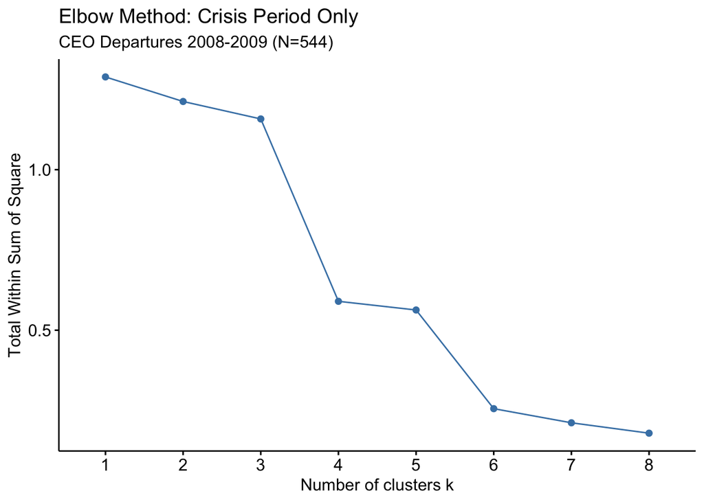

```r
# Crisis departures only (544 documents)
crisis_docs <- lsa_docs[ceo_pam$period == "crisis", ]

# Elbow method for crisis
fviz_nbclust(
  crisis_docs,
  pam,
  method = "wss",
  k.max = 8        # Max 8 since only 544 docs
) +
  labs(
    title = "Elbow Method: Crisis Period Only",
    subtitle = "CEO Departures 2008-2009 (N=544)"
  )
```

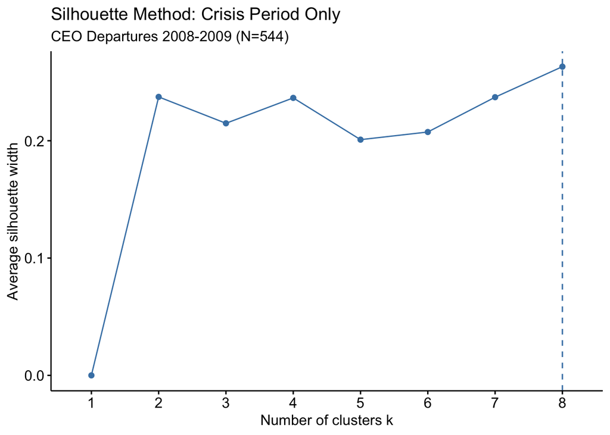

```r
# Silhouette method for crisis
fviz_nbclust(
  crisis_docs,
  pam,
  method = "silhouette",
  k.max = 8
) +
  labs(
    title = "Silhouette Method: Crisis Period Only",
    subtitle = "CEO Departures 2008-2009 (N=544)"
  )
```

For crisis departures, the elbow plot showed us a clear bend at k=4. The silhouette scores were similar across k=3-8 (all around 0.20-0.27). Given the plots we decided to chose k=4.

Now, for the normal departures we also create both plots.

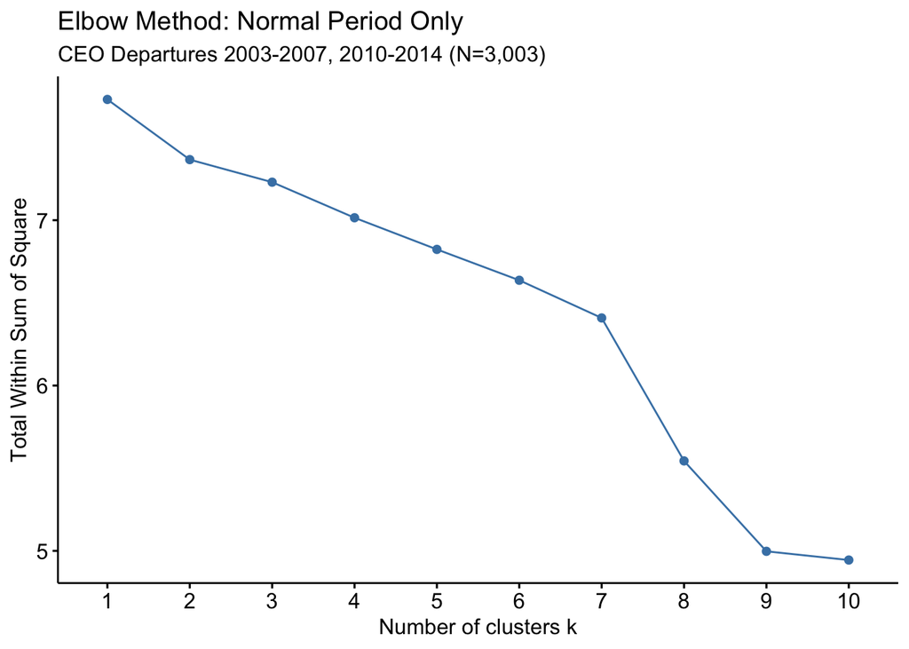

```r
# Normal departures only (3,003 documents)
normal_docs <- lsa_docs[ceo_pam$period == "normal", ]

# Elbow method for normal
fviz_nbclust(
  normal_docs,
  pam,
  method = "wss",
  k.max = 10
) +
  labs(
    title = "Elbow Method: Normal Period Only",
    subtitle = "CEO Departures 2003-2007, 2010-2014 (N=3,003)"
  )
```

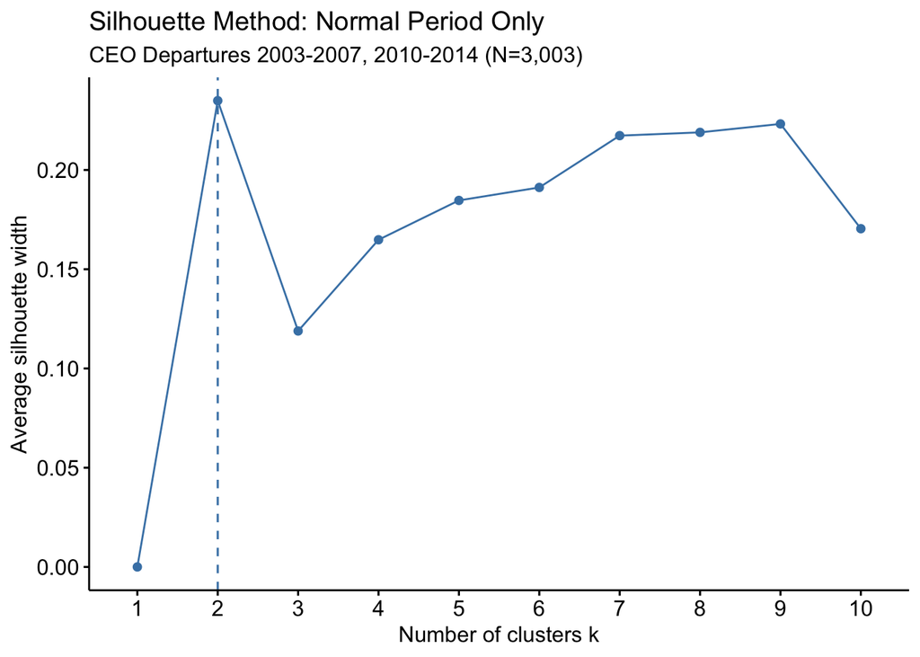

```r
# Silhouette method for normal
fviz_nbclust(
  normal_docs,
  pam,
  method = "silhouette",
  k.max = 10
) +
  labs(
    title = "Silhouette Method: Normal Period Only",
    subtitle = "CEO Departures 2003-2007, 2010-2014 (N=3,003)"
  )
```

For normal departures, the silhouette plot showed a clear peak at k=2 (silhouette = 0.23), which dropped sharply to 0.12 at k=3. Even though silhouette improved again at k=7-9, we chose k=2 because it had the highest score. The elbow plot didn’t show a clear bend, so we decided to rely on the silhouette evidence.

It is interesting to notice that the optimization revealed different optimal k values for each period: k=4 for crisis (based on clear elbow) and k=2 for normal (based on peak silhouette). This difference itself is meaningful, crisis departures naturally seem to divide into four types while normal departures split into two broad categories.

Now, we can run our k-medoids clustering on the crisis and normal subsets.

```r
# We run crisis PAM with k=4
set.seed(2025)
pam_crisis_final <- pam(crisis_docs, k = 4)

# Normal PAM with k=2
set.seed(2025)
pam_normal_final <- pam(normal_docs, k = 2)

# Check cluster sizes
print(table(pam_crisis_final$clustering))
```

```
  1   2   3   4
201 273  69   1
```

```r
print(table(pam_normal_final$clustering))
```

```
   1    2
1478 1525
```

Clustering each period separately shows different patterns. Crisis departures split into four uneven groups (201, 273, 69, and 1), while normal departures split into two balanced groups (1,478 and 1,525). This suggests crisis might create more varied communication approaches, while normal times show simpler variation. The uneven crisis cluster sizes, including one with just a single departure, hint at more diverse responses during economic stress compared to the more standardized two-pattern split in normal times.

We now look into the medoids of each cluster to understand the patterns.

```r
# We subset crisis medoids
crisis_medoid_indices <- pam_crisis_final$id.med

crisis_departures <- ceo_analysis |>
  filter(period == "crisis")

crisis_medoid_notes <- crisis_departures$notes[crisis_medoid_indices]

# We display crisis notes in readable format
for(i in 1:length(crisis_medoid_notes)) {
  cat("\n--- Crisis Cluster", i, "medoid ---\n")
  cat(crisis_medoid_notes[i], "\n")
}
```

```
--- Crisis Cluster 1 medoid ---
The chief executive of FirstFed Financial Corp. is resigning after 13 years at the helm of the Los Angeles savings and loan, whose fortunes rose and fell with the boom and bust in pay-option mortgages. December 11, 2009, FirstFed Financial Corp. announced today that Babette Heimbuch, chairman and ch…

--- Crisis Cluster 2 medoid ---
Arie Cohen, the Company’s President and Chief Executive Officer, left the Company to pursue other interests. The question remains what exactly was behind the move by Cohen? Was he pushed out, does he have a possible opportunity and, if so, why would it be better than his previous position at CardioN…
  In an April 24 report, Jefferies & Co. analyst Brian Kennedy accurately predicted a dire cut in the price Medicare pays for CardioNet's remote heart-monitoring system. The call would have protected anyone heeding his advice from potentially big losses in the stock, which is down 78% since the repo…

--- Crisis Cluster 3 medoid ---
CEO stepped down after 40 years with the company and stayed on as the Chairman to assist the board with the new CEO's transition

--- Crisis Cluster 4 medoid ---
Merger
```

```r
# We do the same for normal medoids
normal_medoid_indices <- pam_normal_final$id.med

normal_departures <- ceo_analysis |>
  filter(period == "normal")

normal_medoid_notes <- normal_departures$notes[normal_medoid_indices]

for(i in 1:length(normal_medoid_notes)) {
  cat("\n--- Normal Cluster", i, "medoid ---\n")
  cat(normal_medoid_notes[i], "\n")
}
```

```
--- Normal Cluster 1 medoid ---
Express, Inc. (NYSE: EXPR), a specialty retail apparel chain operating approximately 630 stores, today announced that Chairman and Chief Executive Officer, Michael Weiss, will retire as Chief Executive Officer on January 30, 2015. Mr. Weiss' career with Express began more than 30 years ago when, in …

--- Normal Cluster 2 medoid ---
Coverage says that Meyers resigned after less than a year as CEO. The company said that it is anticipating improving economic conditions to help them meet their goals.
```

Looking at the medoid examples from crisis and normal periods, we see potential differences in how companies communicate CEO departures.

Crisis appears to show more variation in detail level. The four crisis medoids range from very brief (Cluster 4: just “Merger”) to quite detailed (Cluster 1: multiple sentences explaining the business context and succession plan). Crisis Cluster 1’s medoid explicitly mentions “boom and bust in pay-option mortgages,” directly connecting the departure to economic conditions. Crisis Cluster 2’s medoid discusses stock decline and raises questions about the true reasons for departure. This range suggests crisis-period companies vary in how much context they provide - some explain extensively, others keep it minimal.

Normal appears to show simpler patterns. The two normal medoids differ mainly in length and tone. Normal Cluster 1’s medoid is longer and more celebratory, describing a 30-year career and expansion achievements. Normal Cluster 2’s medoid is shorter and more neutral, simply stating the CEO resigned and the company anticipates improving conditions. This suggests normal-period departures split between detailed positive narratives and brief factual announcements.

In terms of bringing it back to our reseach question, we can see that these examples suggest crisis and normal periods may organize departure communications differently. Crisis seems to vary in detail/transparency, meaning how much to explain about circumstances. Normal subset seems to vary in tone, meaning whether to celebrate or just state facts. However, we need to examine more departures from each cluster beyond just the medoids to confirm if this pattern holds across more cluster entries.

To do that, we examine more notes.

```r
# Get 3 random examples from each crisis cluster
set.seed(123)

crisis_examples <- ceo_analysis |>
  filter(period == "crisis") |>
  mutate(cluster = pam_crisis_final$clustering) |>
  group_by(cluster) |>
  slice_sample(n = 3) |>  # 3 random from each cluster
  ungroup() |>
  select(cluster, coname, exec_fullname, fyear, notes)

# Print by cluster
for(i in 1:4) {
  cat("\n=== CRISIS CLUSTER", i, "EXAMPLES ===\n")
  cluster_i <- crisis_examples |> filter(cluster == i)
  for(j in 1:nrow(cluster_i)) {
    cat("\nExample", j, ":", cluster_i$coname[j], "-", cluster_i$exec_fullname[j], "(", cluster_i$fyear[j], ")\n")
    cat(cluster_i$notes[j], "\n")
  }
}
```

```
=== CRISIS CLUSTER 1 EXAMPLES ===

Example 1 : BLOCK H & R INC - Russell P. Smyth ( 2009 )
Russell P. Smyth provided H&R Block, Inc. (NYSE: HRB) with notice of his resignation as President and Chief Executive Officer of the Company, and as a director of the Company. The effective date of Mr. Smyth’s resignation from these positions is August 29, 2010, unless the Board of Directors selects…

Example 2 : SYNOVUS FINANCIAL CORP - Kessel D. Stelling Jr. ( 2009 )
Execucomp error

Example 3 : WILLIAMS-SONOMA INC - W. Howard Lester ( 2009 )
During Mr. Lester's tenure with the company, he held the positions of President, Chief Executive Officer and Chairman of the Board. He served as Chairman of the Board from 1986 to 2010, and as Chief Executive Officer from 1979 to 2001 and again from 2006 through his retirement in May 2010.

=== CRISIS CLUSTER 2 EXAMPLES ===

Example 1 : ZALE CORP - Neal Goldberg ( 2009 )
Goldberg, resigned as Chief Executive Officer after Zales deided to change upper managament. This was a result of poor performances by Zales. Neal was known for his critique about jewelry comapnies and their outdated pracitces even his own company. The company had market shares fall 7% and revenue t…

Example 2 : FIRST HORIZON NATIONAL CORP - Gerald L. Baker ( 2008 )
Company struggled financially under his leadership

Example 3 : XPERI CORPORATION - Bruce M. McWilliams ( 2008 )
Mr. McWilliam stepped down as President and CEO of XPERI in August 2008. He transitioned to a role in Chief Strategy Officer and remained as the Chairman of the Board. Although XPERI said that the executive change was needed to focus on longer-tern strategy, it seemed like XPERI was not doing well i…

=== CRISIS CLUSTER 3 EXAMPLES ===

Example 1 : CONVERGYS CORP - David F. Dougherty ( 2009 )
Dougherty voluntarily stepped into retirement from his career as CEO to pursue his interests such as tennis.

Example 2 : ARAMARK CORP - Joseph Neubauer ( 2008 )
Performance appears to have been fine when he eventually retired. This was 8 years after the former CEO left and he took back over. This individual has been in and out of aramark for a long time and at one point took it private

Example 3 : SHFL ENTERTAINMENT INC - Timothy J. Parrott ( 2009 )
He left after a medical problem and passed away soon after. This was at least the second medical leave he took while runnign the company.  Peckman took over as interim to handle duties

=== CRISIS CLUSTER 4 EXAMPLES ===

Example 1 : TERRA INDUSTRIES INC - Michael Lynn Bennett ( 2008 )
Merger
```

```r
# We also get 3 examples from each normal cluster
set.seed(123)

normal_examples <- ceo_analysis |>
  filter(period == "normal") |>
  mutate(cluster = pam_normal_final$clustering) |>
  group_by(cluster) |>
  slice_sample(n = 3) |>
  ungroup() |>
  select(cluster, coname, exec_fullname, fyear, notes)

# Print by cluster
for(i in 1:2) {
  cat("\n=== NORMAL CLUSTER", i, "EXAMPLES ===\n")
  cluster_i <- normal_examples |> filter(cluster == i)
  for(j in 1:nrow(cluster_i)) {
    cat("\nExample", j, ":", cluster_i$coname[j], "-", cluster_i$exec_fullname[j], "(", cluster_i$fyear[j], ")\n")
    cat(cluster_i$notes[j], "\n")
  }
}
```

```
=== NORMAL CLUSTER 1 EXAMPLES ===

Example 1 : USG CORP - William C. Foote ( 2010 )
USG Corporation announced today that effective January 1, 2011, James S. Metcalf, currently President and Chief Operating Officer, will become Chief Executive Officer and President, succeeding William C. Foote as CEO. These changes continue the implementation of an ongoing executive succession plan …

Example 2 : TECO ENERGY INC - Robert D. Fagan ( 2004 )
Coverage says that Fagan will retire in several months but the company has elected a new CEO effective immidiately. Fagan will only serve on the board until his retirement date.

Example 3 : NOBLE CORP PLC - James C. Day ( 2007 )
It was announced today that James C. Day, Chairman and Chief Executive officer of Noble Corporation, will retire effective April 30, 2007. This announcement is consistent with a long standing succession planning process within Noble Corporation. Mr. Day will retire from the Board and the Company aft…

=== NORMAL CLUSTER 2 EXAMPLES ===

Example 1 : BORGWARNER INC - Timothy M. Manganello ( 2012 )
Mr.Manganello served as the CEO of Borgwarner Inc for 10 years. He was 62 when he retired from the position of CEO. He remained executive chairman after his retirement. He retired as executive chairman in April 2013.

Example 2 : B/E AEROSPACE INC - Robert J. Khoury ( 2005 )
B/E Aerospace, Inc. announced on 8 Nov. 2005 that its President and C.E.O. Robert J. Khoury would retire on New Year's Eve from his positions, with Mr. Baughan and Amin Khoury succeeding him in said roles respectively. He stated, "'I'm proud of our accomplishments but I now look forward to spending …

Example 3 : PLATINUM UNDERWRITERS HLDG - Michael David Price ( 2014 )
Platinum combined with RenRe to give them bigger US Causualty Shares after Ren re paid $11.9 Billion for them. Mike Price decided not to join the companies as they combined and therefore stepped down from his role as CEO after the two companies became one.
```

Looking at the cluster examples shows us an important difference between how crisis and normal periods organize CEO departure communications.

Crisis clusters differ in how much companies explain. Some crisis departures openly discuss performance problems (falling market share, financial struggles), while others focus on personal reasons (retirement plans, health issues) or just announce the transition without mentioning problems. This suggests crisis creates a difficult choice for companies: should we explain what went wrong or not?

Normal clusters differ in how much companies celebrate. Some normal departures emphasize long careers and careful succession planning, while others simply state the facts briefly. The choice seems to be about how positive and detailed to be, not whether to acknowledge problems.

Crisis and normal periods create different communication challenges. During crisis, companies face a transparency question, whether to acknowledge business difficulties. During normal times, companies face a tone question, whether to elaborate on achievements or keep it brief. This difference might explain why crisis produced more cluster types (4) than normal (2), the transparency decision creates more possible responses than the tone decision.

However, it’s important to acknowledge that we’re looking at small samples, so these patterns may not hold for all departures in each cluster.

### Final Findings: How Crisis and Normal Periods Are Different

Our analysis using keyness, BERTopic, and clustering shows us patterns in how CEO departures are documented across crisis and normal periods. We note that our dataset seems to contains a mix of original announcements and researcher summaries, so these patterns may reflect differences in documentation rather than purely corporate communication choices.

**Vocabulary differences (from keyness)**

Looking at which words distinguish the periods, we found that some of the crisis departures mentioned “recession” explicitly to explain problems, while normal departures used words like “personal” and “elected” to frame exits as individual choices. Crisis notes also had more company-specific names (Wilmington, Motorola, Exxon), possibly because certain industries faced concentrated problems during 2008-2009. This suggests companies might attribute departures to external forces during crisis but to internal factors during stable times.

**Thematic differences (from BERTopic)**

BERTopic showed us that while most topics appear in both periods, their relative prevalence cahnges. Example documents showed that crisis-heavy topics tend to involve external pressure or difficult circumstances, while normal-heavy topics feature more routine transitions. However, these differences were modest, suggesting crisis shifts the emphasis rather than creating entirely new narrative categories.

**Structural differences (from clustering)**

When we clustered each period separately, we noticed different patterns. Crisis split into four types with uneven sizes, while normal split into two balanced types. Looking at examples from each cluster, crisis narratives seemed to vary in how much detail they provided, some explained problems extensively while others stayed brief. Normal narratives seemed to vary more in tone, some celebrated careers while others just stated facts.

**What this tells us**

Now we are ready to answer our main research question: Do CEO departure narratives fundamentally change during economic crises compared to normal times? Our analysis suggests the answer is both yes and no. Crisis doesn’t appear to create entirely different narrative structures, meaning that when we clustered all departures together, crisis and normal mixed proportionally in every cluster rather than separating into distinct groups. This indicates companies use similar underlying templates regardless of economic period. BERTopic supports this, all of the 11 topics appear in both periods, just with different frequencies.

However, crisis does seem to shape communication in three ways. First, it might change vocabulary choice, meaning companies explicitly state recession and external economic forces during crisis while using personal and internal reasons during normal times. Second, it shifts thematic emphasis, with crisis departures more likely to involve pressure or abrupt changes. Third, it appears to create more varied strategic responses. So crisis doesn’t totally transform departure communication, but it does seem to complicate it, adding external blame language, shifting thematic focus, and creating more diverse approaches as companies navigate difficult times.

### Implications for Stakeholders

For investors and analysts reading CEO departure announcements, our findings suggest that it is importan to pay attention to what isn’t said as much as what is. During crisis periods, explicit mention of economic conditions may signal that boards are framing departures defensively, while silence about broader context doesn’t necessarily mean the departure is unrelated to economic pressures. For boards and communications teams, our analysis might suggest that crisis doesn’t require fundamentally different announcement templates, meaning the same narrative structures appear in both periods, just with different vocabulary choices. Finally, for researchers studying corporate communication, the high outlier rate in topic modeling (40%) and weak clustering separation suggest that CEO departure announcements may be more formulaic than thematically different, making them challenging subjects for text-based classification.

### Limitations

**Crisis period definition**

We defined crisis as 2008-2009 and normal as 2003-2007 plus 2010-2014, but economic stress doesn’t follow strict year boundaries. It is important to note that some 2007 departures we classified as “normal” might already reflect emerging financial problems, while some 2010 departures might still involve crisis environment. Drawing such a sharp line is somewhat artificial and likely doesn’t capture all the actual differences.

**Unequal sample sizes**

Our dataset contains about five times more normal-period departures (3,003) than crisis-period departures (544). This imbalance creates challenges when comparing patterns between periods. Smaller samples generally provide less reliable evidence of underlying patterns, so we have less confidence in conclusions drawn from the crisis subset. Additionally, with fewer crisis cases overall, we may have missed less common communication approaches that simply didn’t appear often enough in our limited crisis sample.

**Limited close reading**

Throughout our analysis, when examining specific patterns we typically looked at 3-5 example documents per topic or cluster. With over 3,500 departure notes with varying sizes, reading much more of them in detail was not feasible. This means our interpretations of what each topic or cluster represents are based on small samples that may not capture the full range of documents within each group. A document we didn’t examine might tell a different story than the examples we selected. Our findings should therefore be understood as patterns suggested by representative examples rather than comprehensive characterizations of every departure in each category.

**Industry challenges**

The financial sector and manufacturing appear heavily in our crisis sample (Wilmington Trust, Motorola, Exxon) because these industries suffered disproportionately during 2008-2009. What we’re calling “crisis patterns” might actually be “financial sector patterns during crisis.” We cannot truly separate whether differences come from economic timing or from which industries experienced departures when.

**Text being a constructed data**

The departure notes in our dataset are a mix of different sources, some are summaries written by researchers compiling information from news articles and SEC filings, while others appear to be excerpts from original corporate announcements. This means we’re not always analyzing what companies actually said, but sometimes analyzing researchers’ interpretations and summaries of what happened. Different researchers might have summarized the same departure differently, and their choices about what to include or emphasize could create patterns in our data that don’t reflect actual differences in corporate communication strategies.

**Limited generalizability**

It is important to note that our dataset only includes S&P 1500 firms, large, publicly traded companies with professional communications teams. Our findings may not apply to smaller companies, private firms, or international corporations. SImilarly, our findings come from our analysis of one specific crisis period, so we present them as suggestive patterns rather than definitive conclusions. Economic context appears to play a role in shaping corporate communication, but the strength of its influence is uncertain given the many other factors that shape how companies announce CEO departures.

### Ethical Considerations

**Real people involved**

This analysis focuses on CEO departures, but these involve real people with careers and reputations at stake. Learning about 2008 crisis showed me that it affected not just corporations but ordinary families and communities. The executives in our dataset cannot respond to our analysis or provide context beyond what appears in the notes. When using CEO dataset or our analysis one should be cautious about judging decisions made during extraordinary circumstances.

**Potential for misuse**

Our findings identify patterns in how departures are described during difficult times. This information could be used to detect when companies are struggling, but it could also be used to craft announcements that hide problems more effectively. Research intended to improve understanding can sometimes become a tool for misinformation instead, and it is important to prevent that,

**Power imbalances**

CEO departures affect different people differently. Institutional investors have teams who can analyse announcements and act quickly. Employees might learn about leadership changes from the same announcements but might be not able to interpret what the language might mean for their jobs. Our analysis of communication patterns is likely more useful to those who already have resources to act on such insights than to those most affected by the departures themselves.

**Systemic context**

The 2008-2009 crisis was a systemic failure affecting entire industries. Companies faced competing demands - transparency for investors, reassurance for employees, legal protection - simultaneously. Communication choices during crisis reflect genuine difficulty, not necessarily deception.

**Limits of text analysis**

Finally, we need to acknowledge what this analysis can’t reveal. We found patterns in language, but we can’t know what people were actually thinking or why boards made their decisions. We don’t know what information was available when departure descriprions were written, or what pressures companies faced. Our methods can identify which words appear more often in different contexts, but they can’t tell us about the reasons behind those choices or the circumstances people were navigating. Before drawing conclusions about companies or individuals based on these findings, we should remember that behind each departure is a person navigating a complex situation our analysis cannot fully capture.

### Generative AI Use

- I used Claude AI to help write code for displaying results in readable formats. For example, when I needed to print out medoid notes or cluster examples, I would tell Claude what R objects I had (like `notes-by-same-dominant-topic` and ask it to write `cat()`loops to display them clearly. This saved time formatting outputs and made my results presentation more organized.
- I used Claude AI to help structure code for extracting top examples from each topic in the `notes-by-dominant-topic` code chunk. Claude provided an initial approach using `map_df()` to iterate through topics and find documents with highest probabilities, which I then edited to fit my specific needs. I changed the number of examples, adjusting which variables to select, and modifying how the results were organized. This helped me understand how to efficiently extract and organize topic model results rather than manually subsetting the data for each topic.
- I used Claude AI to help me set up and debug BERTopic initialization locally on my laptop. I also used Claude to learn how to make the results reproducible, meaning I got the suggestion to specify UMAP and implemented the code myself.
- I used Grammarly to proofread Findings, Limitations and Ethical Considerations parts of the assignment for grammatical, spelling and punctuation errors. After Grammarly identified areas for improvement, I edited problematic parts myself.